# Tugas Individu MPDW

Alista Sava Davina

2024-08-25

# Inisialisasi Library

```r
library(forecast)
```

```r
library(graphics)
library(TTR)
library(TSA)
library(ggplot2)
library(tsibble)
library(tseries)
library(MASS)
library(aTSA)
```

# Impor Data

```r
data <- read.csv("C:/Users/Alista/Documents/Semester 5/Metode Peramalan Deret Waktu MPDW/Data Individu Toll.csv", sep = ";")
str(data)
```

```
## 'data.frame':    100 obs. of  2 variables:
##  $ Periode  : int  101 102 103 104 105 106 107 108 109 110 ...
##  $ Kendaraan: int  24719 22940 19933 26093 26724 29783 30335 24283 24110 24492 ...
```

# Eksplorasi Data

```r
data.ts <- ts(data$Kendaraan)
summary(data.ts)
```

```
##    Min. 1st Qu.  Median    Mean 3rd Qu.    Max.
##   19933   24784   25980   26863   29680   38617
```

Membuat Plot Deret Waktu

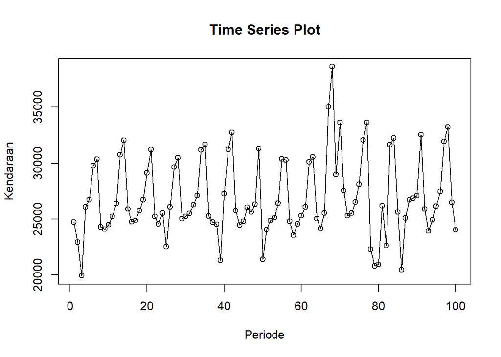

```r
ts.plot(data.ts, xlab="Periode", ylab="Kendaraan",
        main = "Time Series Plot")
points(data.ts)
```

# Single Moving Average & Double Moving Average ## Pembagian Data Data Latih : Data Uji = 80% : 20%

```r
training_ma <- data[1:80,]
testing_ma <- data[81:100,]
train_ma.ts <- ts(training_ma$Kendaraan)
test_ma.ts <- ts(testing_ma$Kendaraan)
```

## Eksplorasi Data

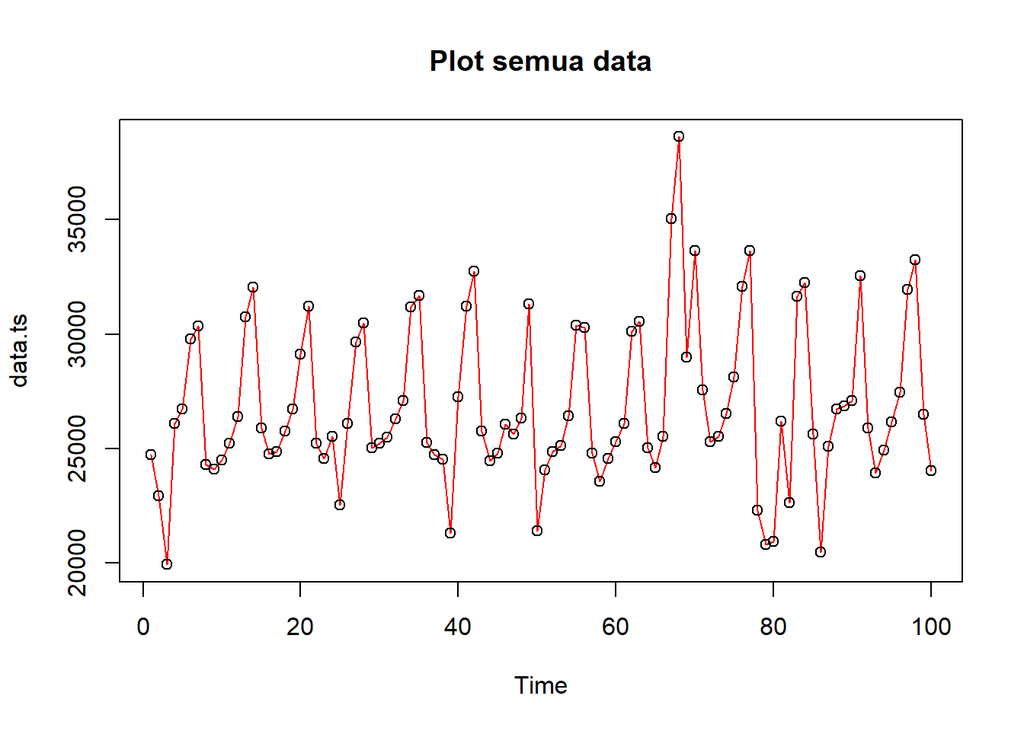

```r
#eksplorasi keseluruhan data
plot(data.ts, col="red", main="Plot semua data", type="o")
points(data.ts)
```

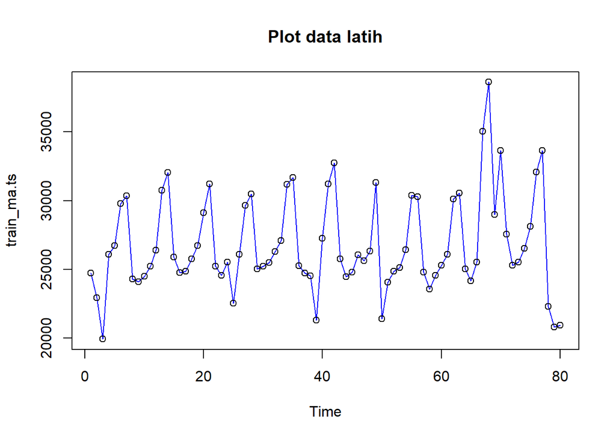

```r
#eksplorasi data latih
plot(train_ma.ts, col="blue",main="Plot data latih", type="o")
points(train_ma.ts)
```

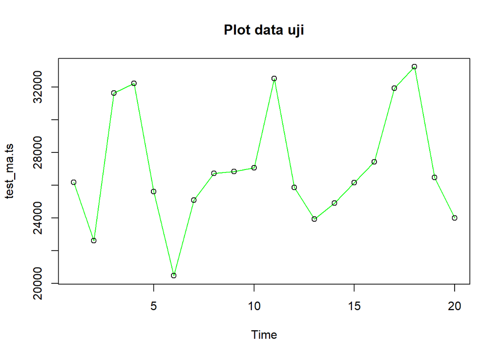

```r
#eksplorasi data uji
plot(test_ma.ts, col="green",main="Plot data uji", type="o")
points(test_ma.ts)
```

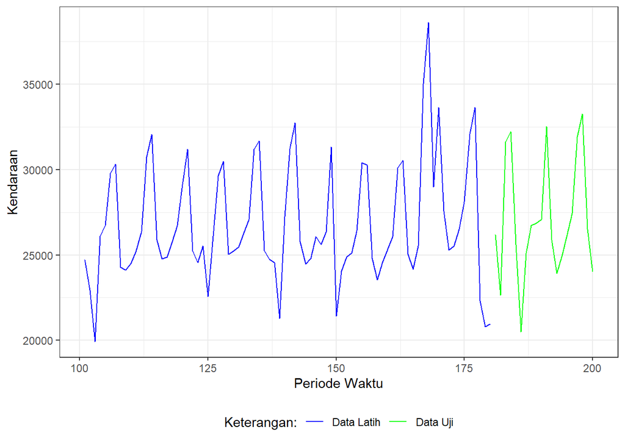

```r
#eksplorasi dengan ggplot
ggplot() +
  geom_line(data = training_ma, aes(x = Periode, y = Kendaraan, col = "Data Latih")) +
  geom_line(data = testing_ma, aes(x = Periode, y = Kendaraan, col = "Data Uji")) +
  labs(x = "Periode Waktu", y = "Kendaraan", color = "Legend") +
  scale_colour_manual(name="Keterangan:", breaks = c("Data Latih", "Data Uji"),
                      values = c("blue", "green")) +
  theme_bw() + theme(legend.position = "bottom",
                     plot.caption = element_text(hjust=0.5, size=12))
```

# Single Moving Average (SMA) Melakukan pemulusan dengan parameter m = 4

```r
data.sma<-SMA(train_ma.ts, n=4)
data.sma
```

```
## Time Series:
## Start = 1
## End = 80
## Frequency = 1
##  [1]       NA       NA       NA 23421.25 23922.50 25633.25 28233.75 27781.25
##  [9] 27127.75 25805.00 24525.25 25050.75 26714.25 28604.75 28774.50 28368.25
## [17] 26894.50 25324.25 25534.50 26624.00 28207.50 28069.00 27524.00 26628.50
## [25] 24465.25 24687.50 25959.75 27198.00 27817.75 27597.75 26556.50 25509.00
## [33] 26024.75 27516.75 29069.50 28806.50 28219.75 26556.75 23957.75 24458.75
## [41] 26075.50 28128.00 29245.75 28550.50 26945.50 25273.25 25234.50 25700.75
## [49] 27333.00 26170.00 25782.25 25417.00 23870.50 25124.50 26708.00 28057.25
## [57] 27971.50 27253.50 25795.75 24554.75 24878.75 26519.25 28013.25 27946.00
## [65] 27465.00 26319.00 27445.25 30840.00 32044.25 34074.25 32203.50 28873.50
## [73] 28012.00 26227.75 26369.75 28065.75 30091.75 29040.00 27207.25 24423.25
```

Data pemulusan pada periode ke-t selanjutnya digunakan sebagai nilai peramalan pada periode ke t+1 sehingga hasil peramalan 1 periode ke depan adalah seperti berikut:

```r
#forecast 1 periode ke depan
data.ramal<-c(NA,data.sma)
data.ramal
```

```
##  [1]       NA       NA       NA       NA 23421.25 23922.50 25633.25 28233.75
##  [9] 27781.25 27127.75 25805.00 24525.25 25050.75 26714.25 28604.75 28774.50
## [17] 28368.25 26894.50 25324.25 25534.50 26624.00 28207.50 28069.00 27524.00
## [25] 26628.50 24465.25 24687.50 25959.75 27198.00 27817.75 27597.75 26556.50
## [33] 25509.00 26024.75 27516.75 29069.50 28806.50 28219.75 26556.75 23957.75
## [41] 24458.75 26075.50 28128.00 29245.75 28550.50 26945.50 25273.25 25234.50
## [49] 25700.75 27333.00 26170.00 25782.25 25417.00 23870.50 25124.50 26708.00
## [57] 28057.25 27971.50 27253.50 25795.75 24554.75 24878.75 26519.25 28013.25
## [65] 27946.00 27465.00 26319.00 27445.25 30840.00 32044.25 34074.25 32203.50
## [73] 28873.50 28012.00 26227.75 26369.75 28065.75 30091.75 29040.00 27207.25
## [81] 24423.25
```

Selanjutnya dilakukan peramalan sejumlah data uji yaitu 20 periode.

```r
#forecast 20 periode ke depan
data.gab<-cbind(aktual=c(train_ma.ts,rep(NA,20)),pemulusan=c(data.sma,rep(NA,20)),ramalan=c(data.ramal,rep(data.ramal[length(data.ramal)],19)))
data.gab
```

```
##        aktual pemulusan  ramalan
##   [1,]  24719        NA       NA
##   [2,]  22940        NA       NA
##   [3,]  19933        NA       NA
##   [4,]  26093  23421.25       NA
##   [5,]  26724  23922.50 23421.25
##   [6,]  29783  25633.25 23922.50
##   [7,]  30335  28233.75 25633.25
##   [8,]  24283  27781.25 28233.75
##   [9,]  24110  27127.75 27781.25
##  [10,]  24492  25805.00 27127.75
##  [11,]  25216  24525.25 25805.00
##  [12,]  26385  25050.75 24525.25
##  [13,]  30764  26714.25 25050.75
##  [14,]  32054  28604.75 26714.25
```

[output cut: 86 more lines]

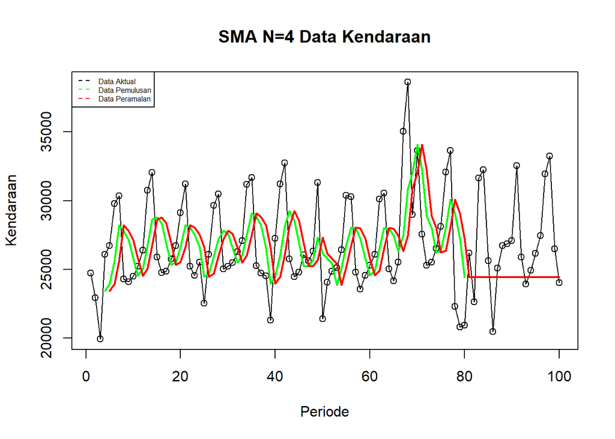

```r
#plot deret waktu hasil peramalan
ts.plot(data.ts, xlab="Periode", ylab="Kendaraan", main= "SMA N=4 Data Kendaraan")
points(data.ts)
lines(data.gab[,2],col="green",lwd=2)
lines(data.gab[,3],col="red",lwd=2)
legend("topleft",c("Data Aktual","Data Pemulusan","Data Peramalan"), lty=8, col=c("black","green","red"), cex=0.5)
```

Selanjutnya perhitungan akurasi dilakukan dengan ukuran akurasi Sum Squares Error (SSE), Mean Square Error (MSE) dan Mean Absolute Percentage Error (MAPE). Perhitungan akurasi dilakukan baik pada data latih maupun pada data uji.

```r
#Menghitung nilai keakuratan data latih
error_train.sma = train_ma.ts-data.ramal[1:length(train_ma.ts)]
SSE_train.sma = sum(error_train.sma[5:length(train_ma.ts)]^2)
MSE_train.sma = mean(error_train.sma[5:length(train_ma.ts)]^2)
MAPE_train.sma = mean(abs((error_train.sma[5:length(train_ma.ts)]/train_ma.ts[5:length(train_ma.ts)])*100))

akurasi_train.sma <- matrix(c(SSE_train.sma, MSE_train.sma, MAPE_train.sma))
row.names(akurasi_train.sma)<- c("SSE", "MSE", "MAPE")
colnames(akurasi_train.sma) <- c("Akurasi m = 4")
akurasi_train.sma
```

```
##      Akurasi m = 4
## SSE   1.386312e+09
## MSE   1.824095e+07
## MAPE  1.365790e+01
```

Dalam hal ini nilai MAPE data latih pada metode pemulusan SMA sebesar 13.66%, nilai ini tidak dapat dikategorikan sebagai nilai akurasi yang sangat baik dikarenakan nilainya melebihi batas MAPE kategori sangat baik yaitu 10%. Selanjutnya dilakukan perhitungan nilai MAPE data uji pada metde pemulusan SMA.

```r
#Menghitung nilai keakuratan data uji
error_test.sma = test_ma.ts-data.gab[81:100,3]
SSE_test.sma = sum(error_test.sma^2)
MSE_test.sma = mean(error_test.sma^2)
MAPE_test.sma = mean(abs((error_test.sma/test_ma.ts*100)))

akurasi_test.sma <- matrix(c(SSE_test.sma, MSE_test.sma, MAPE_test.sma))
row.names(akurasi_test.sma)<- c("SSE", "MSE", "MAPE")
colnames(akurasi_test.sma) <- c("Akurasi m = 4")
akurasi_test.sma
```

```
##      Akurasi m = 4
## SSE   3.745172e+08
## MSE   1.872586e+07
## MAPE  1.138407e+01
```

Perhitungan akurasi menggunakan data latih menghasilkan nilai MAPE yang lebih dari 10% sehingga dapat dikatakan metode Single Moving Avarage (SMA) kurang cocok digunakan.

# Double Noving Average (DMA)

Metode pemulusan Double Moving Average (DMA) pada dasarnya mirip dengan SMA. Namun demikian, metode ini lebih cocok digunakan untuk pola data trend. Proses pemulusan dengan rata rata dalam metode ini dilakukan sebanyak 2 kali.

```r
dma <- SMA(data.sma, n = 4)
At <- 2*data.sma - dma
Bt <- 2/(4-1)*(data.sma - dma)
data.dma<- At+Bt
data.ramal2<- c(NA, data.dma)

t = 1:20
f = c()

for (i in t) {
  f[i] = At[length(At)] + Bt[length(Bt)]*(i)
}

data.gab2 <- cbind(aktual = c(train_ma.ts,rep(NA,20)), pemulusan1 = c(data.sma,rep(NA,20)),pemulusan2 = c(data.dma, rep(NA,20)),At = c(At, rep(NA,20)), Bt = c(Bt,rep(NA,20)),ramalan = c(data.ramal2, f[-1]))
data.gab2
```

```
##        aktual pemulusan1 pemulusan2       At          Bt     ramalan
##   [1,]  24719         NA         NA       NA          NA          NA
##   [2,]  22940         NA         NA       NA          NA          NA
##   [3,]  19933         NA         NA       NA          NA          NA
##   [4,]  26093   23421.25         NA       NA          NA          NA
##   [5,]  26724   23922.50         NA       NA          NA          NA
##   [6,]  29783   25633.25         NA       NA          NA          NA
##   [7,]  30335   28233.75   33118.85 31164.81  1954.04167          NA
##   [8,]  24283   27781.25   30095.52 29169.81   925.70833  33118.8542
##   [9,]  24110   27127.75   27017.33 27061.50   -44.16667  30095.5208
##  [10,]  24492   25805.00   23418.44 24373.06  -954.62500  27017.3333
##  [11,]  25216   24525.25   21550.98 22740.69 -1189.70833  23418.4375
##  [12,]  26385   25050.75   24090.02 24474.31  -384.29167  21550.9792
##  [13,]  30764   26714.25   28698.31 27904.69   793.62500  24090.0208
##  [14,]  32054   28604.75   32573.08 30985.75  1587.33333  28698.3125
```

[output cut: 86 more lines]

Hasil pemulusan dengan menggunakan metode DMA dapat disajikan menggunakan plot sebagai berikut

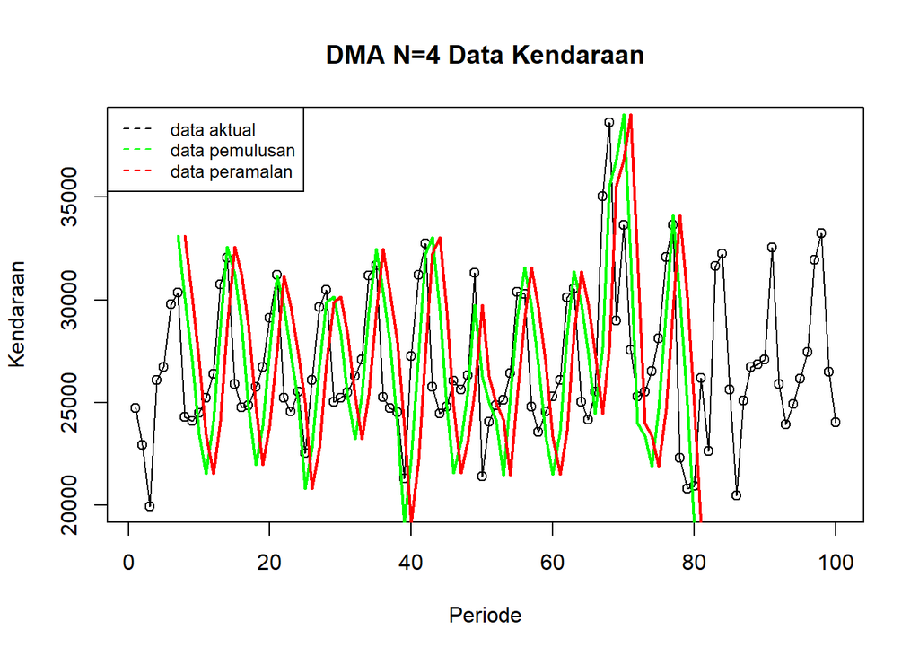

```r
ts.plot(data.ts, xlab="Periode", ylab="Kendaraan", main= "DMA N=4 Data Kendaraan")
points(data.ts)
lines(data.gab2[,3],col="green",lwd=2)
lines(data.gab2[,6],col="red",lwd=2)
legend("topleft",c("data aktual","data pemulusan","data peramalan"), lty=8, col=c("black","green","red"), cex=0.8)
```

Selanjutnya perhitungan akurasi dilakukan baik pada data latih maupun data uji. Perhitungan akurasi dilakukan dengan ukuran akurasi SSE, MSE dan MAPE.

```r
#Menghitung nilai keakuratan data latih
error_train.dma = train_ma.ts-data.ramal2[1:length(train_ma.ts)]
SSE_train.dma = sum(error_train.dma[8:length(train_ma.ts)]^2)
MSE_train.dma = mean(error_train.dma[8:length(train_ma.ts)]^2)
MAPE_train.dma = mean(abs((error_train.dma[8:length(train_ma.ts)]/train_ma.ts[8:length(train_ma.ts)])*100))

akurasi_train.dma <- matrix(c(SSE_train.dma, MSE_train.dma, MAPE_train.dma))
row.names(akurasi_train.dma)<- c("SSE", "MSE", "MAPE")
colnames(akurasi_train.dma) <- c("Akurasi m = 4")
akurasi_train.dma
```

```
##      Akurasi m = 4
## SSE   2.306511e+09
## MSE   3.159604e+07
## MAPE  1.861215e+01
```

Perhitungan akurasi pada data latih menggunakan nilai MAPE menghasilkan nilai MAPE yang lebih dari 10% sehingga tidak dapat dikategorikan sebagai akurasi yang sangat baik. Selanjutnya, perhitungan nilai akurasi dilakukan pada data uji.

```r
#Menghitung nilai keakuratan data uji
error_test.dma = test_ma.ts-data.gab2[81:100,6]
SSE_test.dma = sum(error_test.dma^2)
MSE_test.dma = mean(error_test.dma^2)
MAPE_test.dma = mean(abs((error_test.dma/test_ma.ts*100)))

akurasi_test.dma <- matrix(c(SSE_test.dma, MSE_test.dma, MAPE_test.dma))
row.names(akurasi_test.dma)<- c("SSE", "MSE", "MAPE")
colnames(akurasi_test.dma) <- c("Akurasi m = 4")
akurasi_test.dma
```

```
##      Akurasi m = 4
## SSE    2.01744e+10
## MSE    1.00872e+09
## MAPE   1.05538e+02
```

Pada data latih maupun data uji metode SMA lebih baik dibandingkan dengan metode DMA, dikarenakan menghasilkan nilai MAPE yang lebih kecil. Namun untuk kedua uji tersebut dihasilkan nilai MAPE yang lebih dari 10% sehingga dapat dikatakan bahwa metode SMA maupun DMA kurang cocok digunakan untuk data tersebut.

# Single Exponential Smoothing & Double Exponential Smoothing

Pemulusan dengan metode SES dapat dilakukan dengan dua fungsi dari *packages* berbeda, yaitu (1) fungsi `ses()` dari *packages* `forecast` dan (2) fungsi `HoltWinters` dari *packages* `stats` .

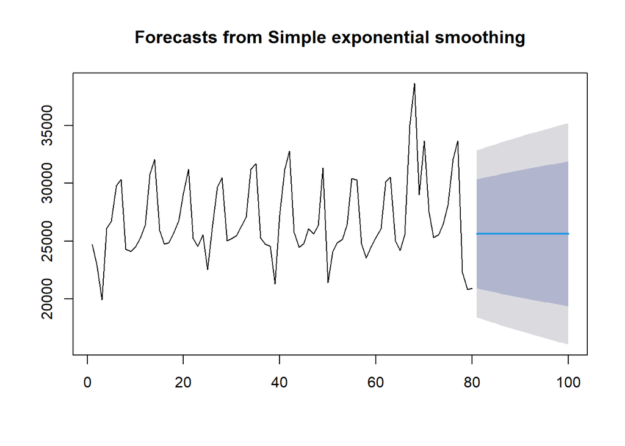

```r
#cara 1: fungsi SES
ses.1 <- ses(train_ma.ts, h = 20, alpha = 0.2)
plot(ses.1)
```

```r
ses.1
```

```
##     Point Forecast    Lo 80    Hi 80    Lo 95    Hi 95
##  81       25628.97 20915.70 30342.23 18420.65 32837.28
##  82       25628.97 20822.36 30435.57 18277.90 32980.03
##  83       25628.97 20730.80 30527.13 18137.87 33120.07
##  84       25628.97 20640.92 30617.02 18000.40 33257.53
##  85       25628.97 20552.63 30705.31 17865.37 33392.56
##  86       25628.97 20465.84 30792.09 17732.65 33525.28
##  87       25628.97 20380.50 30877.43 17602.13 33655.81
##  88       25628.97 20296.52 30961.41 17473.69 33784.24
##  89       25628.97 20213.84 31044.09 17347.24 33910.69
##  90       25628.97 20132.40 31125.53 17222.70 34035.23
##  91       25628.97 20052.16 31205.77 17099.97 34157.96
##  92       25628.97 19973.05 31284.88 16978.99 34278.94
##  93       25628.97 19895.03 31362.90 16859.67 34398.26
##  94       25628.97 19818.06 31439.87 16741.96 34515.97
##  95       25628.97 19742.10 31515.83 16625.78 34632.15
##  96       25628.97 19667.11 31590.83 16511.09 34746.84
##  97       25628.97 19593.04 31664.89 16397.82 34860.11
##  98       25628.97 19519.88 31738.05 16285.92 34972.01
##  99       25628.97 19447.58 31810.35 16175.35 35082.58
## 100       25628.97 19376.11 31881.82 16066.06 35191.88
```

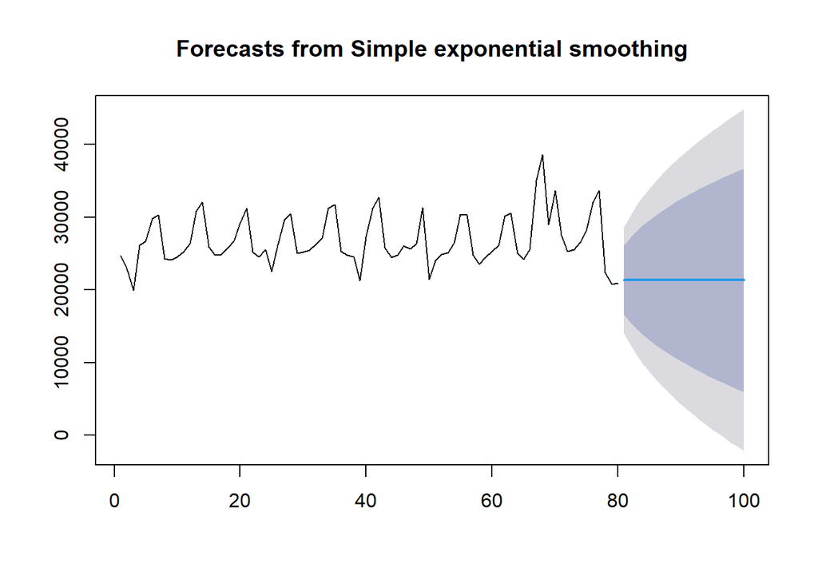

```r
ses.2 <- ses(train_ma.ts, h = 20, alpha = 0.7)
plot(ses.2)
```

```r
ses.2
```

```
##     Point Forecast     Lo 80    Hi 80      Lo 95    Hi 95
##  81       21319.37 16533.869 26104.88 14000.5754 28638.17
##  82       21319.37 15477.921 27160.83 12385.6418 30253.11
##  83       21319.37 14585.571 28053.18 11020.9115 31617.84
##  84       21319.37 13798.362 28840.39  9816.9790 32821.77
##  85       21319.37 13086.080 29552.67  8727.6367 33911.11
##  86       21319.37 12430.693 30208.06  7725.3088 34913.44
##  87       21319.37 11820.417 30818.33  6791.9734 35846.77
##  88       21319.37 11247.051 31391.70  5915.0848 36723.66
##  89       21319.37 10704.610 31934.14  5085.4932 37553.26
##  90       21319.37 10188.573 32450.18  4296.2825 38342.47
##  91       21319.37  9695.422 32943.33  3542.0737 39096.67
##  92       21319.37  9222.359 33416.39  2818.5858 39820.16
##  93       21319.37  8767.111 33871.64  2122.3450 40516.40
##  94       21319.37  8327.807 34310.94  1450.4867 41188.26
##  95       21319.37  7902.879 34735.87   800.6157 41838.13
##  96       21319.37  7491.003 35147.75   170.7050 42468.04
##  97       21319.37  7091.044 35547.70  -440.9790 43079.73
##  98       21319.37  6702.025 35936.72 -1035.9323 43674.68
##  99       21319.37  6323.094 36315.65 -1615.4571 44254.21
## 100       21319.37  5953.505 36685.24 -2180.6949 44819.44
```

Untuk mendapatkan gambar hasil pemulusan pada data latih dengan fungsi `ses()` , perlu digunakan fungsi `autoplot()` dan `autolayer()` dari *library packages* `ggplot2` .

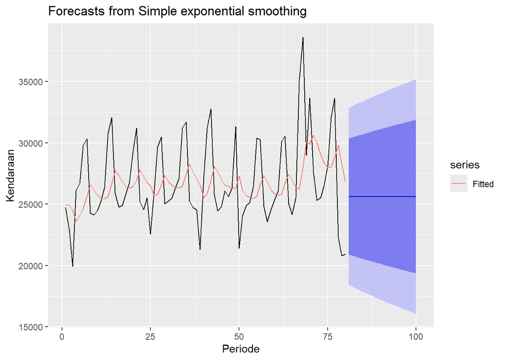

```r
autoplot(ses.1) +
  autolayer(fitted(ses.1), series="Fitted") +
  ylab("Kendaraan") + xlab("Periode")
```

Pada fungsi `ses()` , terdapat beberapa argumen yang umum digunakan, yaitu nilia `y` , `gamma` , `beta` , `alpha` , dan `h` .

Nilai `y` adalah nilai data deret waktu, `gamma` adalah parameter pemulusan untuk komponen musiman, `beta` adalah parameter pemulusan untuk tren, dan `alpha` adalah parameter pemulusan untuk stasioner, serta `h` adalah banyaknya periode yang akan diramalkan.

Kasus di atas merupakan contoh inisialisasi nilai parameter $\lambda$ dengan nilai `alpha` 0,2 dan 0,7 dan banyak periode data yang akan diramalkan adalah sebanyak 20 periode. Selanjutnya akan digunakan fungsi `HoltWinters()` dengan nilai inisialisasi parameter dan panjang periode peramalan yang sama dengan fungsi `ses()` .

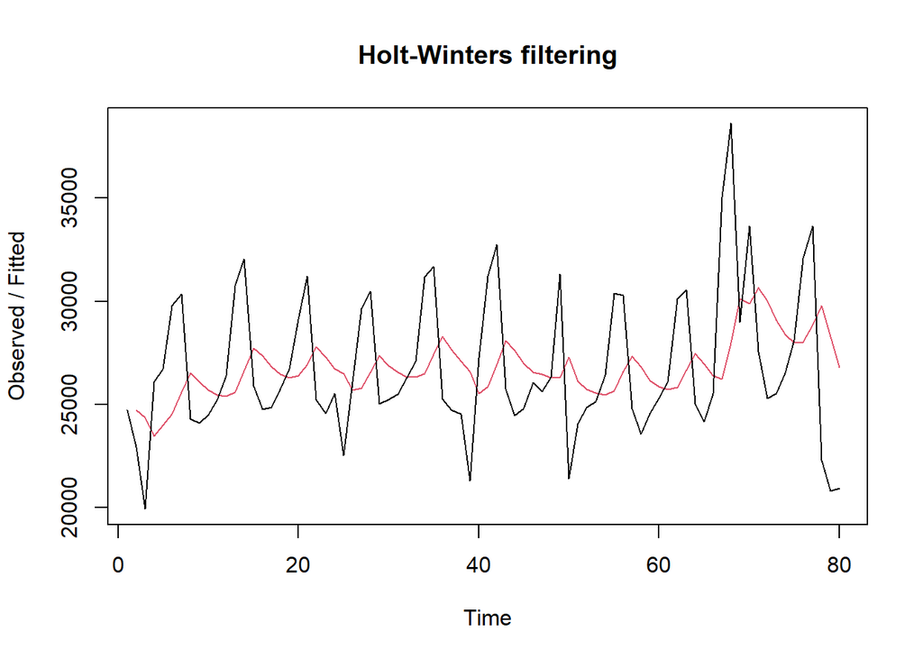

```r
#Cara 2 (fungsi Holtwinter)
ses1<- HoltWinters(train_ma.ts, gamma = FALSE, beta = FALSE, alpha = 0.2)
plot(ses1)
```

```r
#ramalan
ramalan1 <- forecast::forecast(ses1, h = 20)
ramalan1
```

```
##     Point Forecast    Lo 80    Hi 80    Lo 95    Hi 95
##  81       25628.97 20915.89 30342.04 18420.94 32836.99
##  82       25628.97 20822.55 30435.38 18278.19 32979.74
##  83       25628.97 20730.99 30526.94 18138.17 33119.77
##  84       25628.97 20641.12 30616.82 18000.71 33257.22
##  85       25628.97 20552.83 30705.10 17865.68 33392.25
##  86       25628.97 20466.05 30791.88 17732.97 33524.96
##  87       25628.97 20380.71 30877.22 17602.45 33655.48
##  88       25628.97 20296.73 30961.20 17474.02 33783.92
##  89       25628.97 20214.05 31043.88 17347.57 33910.36
##  90       25628.97 20132.62 31125.31 17223.03 34034.90
##  91       25628.97 20052.38 31205.55 17100.31 34157.62
##  92       25628.97 19973.28 31284.66 16979.33 34278.60
##  93       25628.97 19895.26 31362.67 16860.02 34397.91
##  94       25628.97 19818.30 31439.63 16742.31 34515.62
##  95       25628.97 19742.34 31515.59 16626.14 34631.79
##  96       25628.97 19667.35 31590.59 16511.45 34746.48
##  97       25628.97 19593.28 31664.65 16398.19 34859.74
##  98       25628.97 19520.12 31737.81 16286.30 34971.64
##  99       25628.97 19447.83 31810.11 16175.73 35082.20
## 100       25628.97 19376.37 31881.57 16066.44 35191.49
```

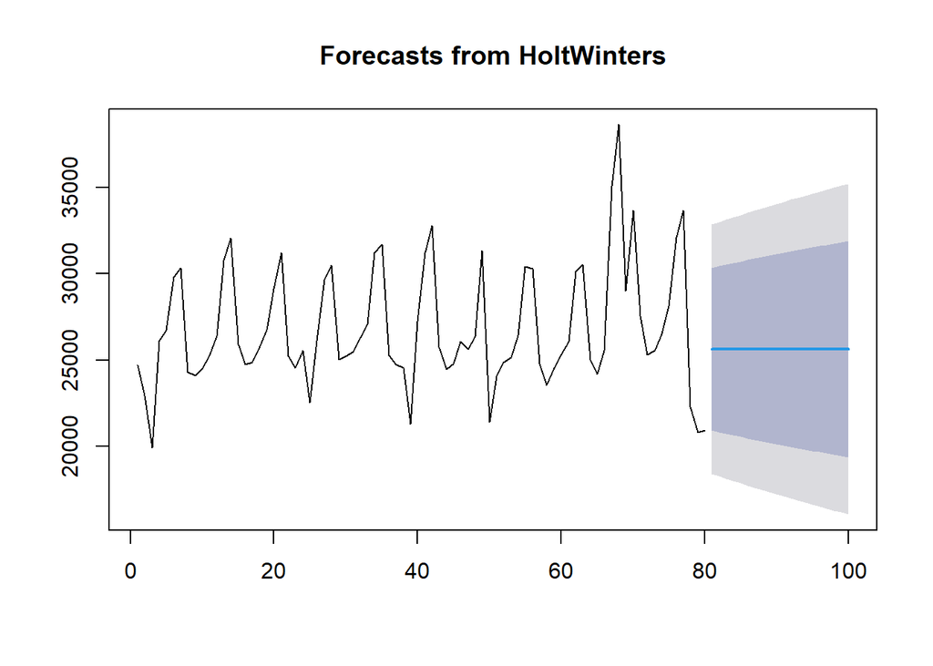

```r
plot(ramalan1)
```

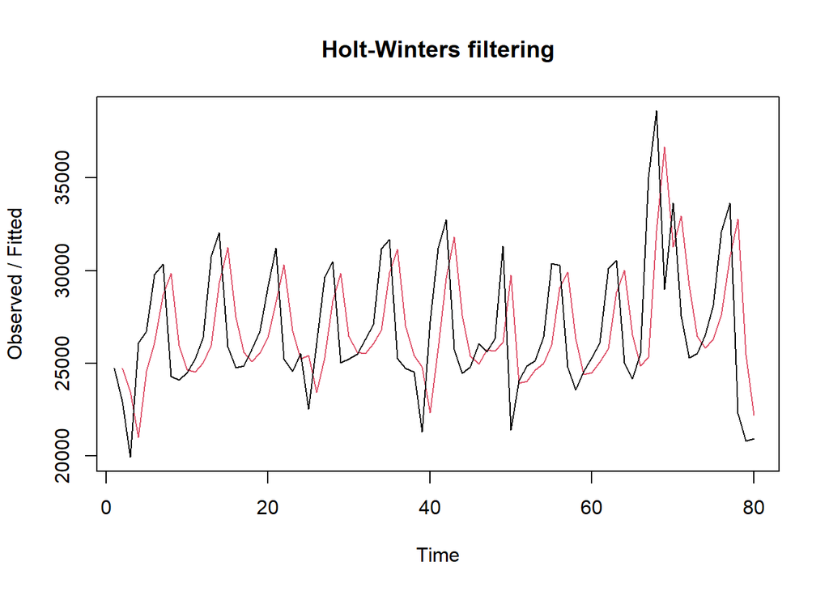

```r
ses2 <- HoltWinters(train_ma.ts, gamma = FALSE, beta = FALSE, alpha = 0.7)
plot(ses2)
```

```r
#ramalan
ramalan2 <- forecast::forecast(ses2, h = 20)
ramalan2
```

```
##     Point Forecast     Lo 80    Hi 80      Lo 95    Hi 95
##  81       21319.37 16533.577 26105.17 14000.1293 28638.62
##  82       21319.37 15477.564 27161.18 12385.0972 30253.65
##  83       21319.37 14585.161 28053.59 11020.2837 31618.46
##  84       21319.37 13797.904 28840.84  9816.2779 32822.47
##  85       21319.37 13085.578 29553.17  8726.8692 33911.88
##  86       21319.37 12430.151 30208.60  7724.4802 34914.27
##  87       21319.37 11819.838 30818.91  6791.0879 35847.66
##  88       21319.37 11246.437 31392.31  5914.1458 36724.60
##  89       21319.37 10703.963 31934.79  5084.5037 37554.24
##  90       21319.37 10187.894 32450.85  4295.2449 38343.50
##  91       21319.37  9694.714 32944.03  3540.9902 39097.76
##  92       21319.37  9221.622 33417.13  2817.4581 39821.29
##  93       21319.37  8766.346 33872.40  2121.1749 40517.57
##  94       21319.37  8327.015 34311.73  1449.2756 41189.47
##  95       21319.37  7902.061 34736.69   799.3650 41839.38
##  96       21319.37  7490.160 35148.59   169.4159 42469.33
##  97       21319.37  7090.177 35548.57  -442.3053 43081.05
##  98       21319.37  6701.134 35937.61 -1037.2949 43676.04
##  99       21319.37  6322.180 36316.57 -1616.8551 44255.60
## 100       21319.37  5952.568 36686.18 -2182.1273 44820.88
```

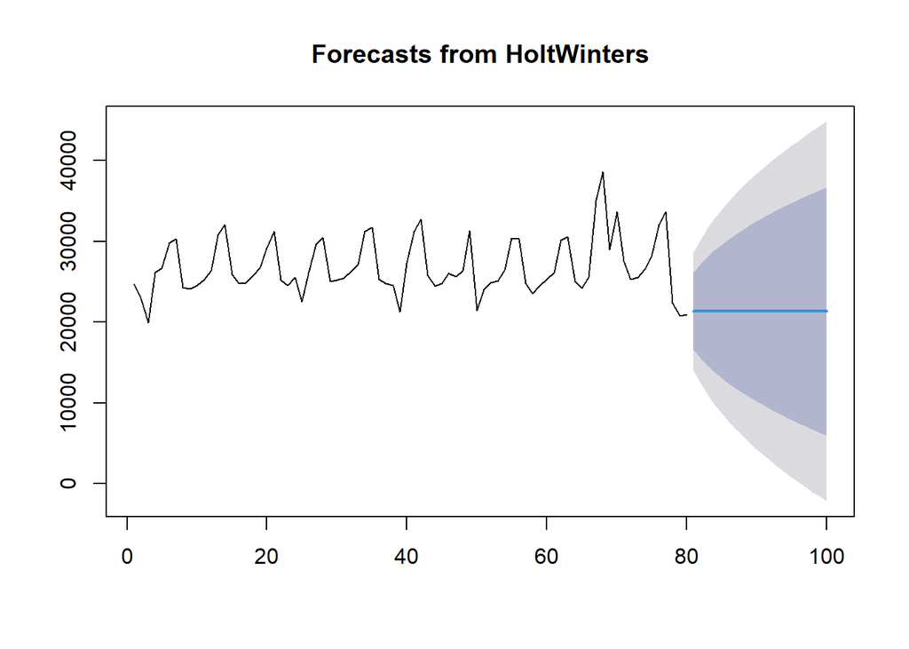

```r
plot(ramalan2)
```

Fungsi `HoltWinters` memiliki argumen yang sama dengan fungsi `ses()` . Argumen-argumen kedua fungsi dapat dilihat lebih lanjut dengan `?ses()` atau `?HoltWinters` .

Nilai parameter $\alpha$ dari kedua fungsi dapat dioptimalkan menyesuaikan dari *error*-nya paling minimumnya. Caranya adalah dengan membuat parameter $\alpha =$ `NULL` .

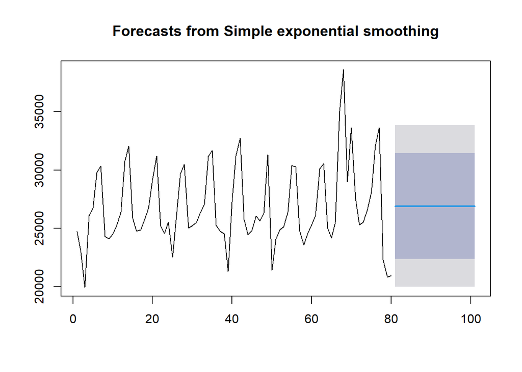

```r
#SES
ses.opt <- ses(train_ma.ts, h = 21, alpha = NULL)
plot(ses.opt)
```

```r
ses.opt
```

```
##     Point Forecast    Lo 80    Hi 80    Lo 95 Hi 95
##  81       26905.81 22370.48 31441.14 19969.62 33842
##  82       26905.81 22370.48 31441.14 19969.62 33842
##  83       26905.81 22370.48 31441.14 19969.62 33842
##  84       26905.81 22370.48 31441.14 19969.62 33842
##  85       26905.81 22370.48 31441.14 19969.62 33842
##  86       26905.81 22370.48 31441.14 19969.62 33842
##  87       26905.81 22370.48 31441.14 19969.62 33842
##  88       26905.81 22370.48 31441.14 19969.62 33842
##  89       26905.81 22370.48 31441.14 19969.62 33842
##  90       26905.81 22370.48 31441.14 19969.62 33842
##  91       26905.81 22370.48 31441.14 19969.62 33842
##  92       26905.81 22370.48 31441.14 19969.62 33842
##  93       26905.81 22370.48 31441.14 19969.62 33842
##  94       26905.81 22370.48 31441.14 19969.62 33842
##  95       26905.81 22370.48 31441.14 19969.62 33842
##  96       26905.81 22370.48 31441.14 19969.62 33842
##  97       26905.81 22370.48 31441.14 19969.62 33842
##  98       26905.81 22370.48 31441.14 19969.62 33842
##  99       26905.81 22370.48 31441.14 19969.62 33842
## 100       26905.81 22370.48 31441.14 19969.62 33842
## 101       26905.81 22370.48 31441.14 19969.62 33842
```

```r
#Lamda Optimum Holt Winter
sesopt <- HoltWinters(train_ma.ts, gamma = FALSE, beta = FALSE,alpha = NULL)
sesopt
```

```
## Holt-Winters exponential smoothing without trend and without seasonal component.
##
## Call:
## HoltWinters(x = train_ma.ts, alpha = NULL, beta = FALSE, gamma = FALSE)
##
## Smoothing parameters:
##  alpha: 0.06554102
##  beta : FALSE
##  gamma: FALSE
##
## Coefficients:
##       [,1]
## a 27092.66
```

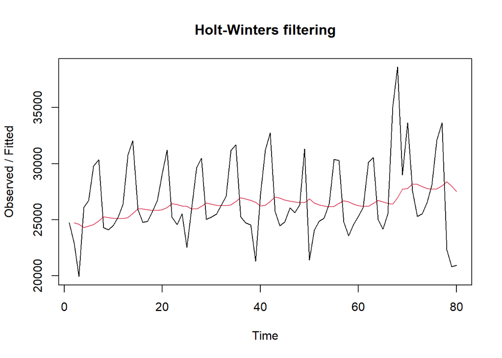

```r
plot(sesopt)
```

```r
#ramalan lamda optimum
ramalanopt <- forecast::forecast(sesopt, h = 20)
ramalanopt
```

```
##     Point Forecast    Lo 80    Hi 80    Lo 95    Hi 95
##  81       27092.66 22480.81 31704.51 20039.44 34145.87
##  82       27092.66 22470.91 31714.40 20024.31 34161.01
##  83       27092.66 22461.04 31724.28 20009.21 34176.11
##  84       27092.66 22451.19 31734.13 19994.14 34191.17
##  85       27092.66 22441.36 31743.96 19979.11 34206.21
##  86       27092.66 22431.55 31753.77 19964.10 34221.22
##  87       27092.66 22421.75 31763.56 19949.13 34236.19
##  88       27092.66 22411.99 31773.33 19934.19 34251.13
##  89       27092.66 22402.24 31783.08 19919.28 34266.04
##  90       27092.66 22392.51 31792.81 19904.40 34280.92
##  91       27092.66 22382.80 31802.52 19889.55 34295.77
##  92       27092.66 22373.11 31812.21 19874.73 34310.59
##  93       27092.66 22363.44 31821.88 19859.94 34325.38
##  94       27092.66 22353.79 31831.53 19845.18 34340.13
##  95       27092.66 22344.16 31841.16 19830.45 34354.86
##  96       27092.66 22334.55 31850.77 19815.76 34369.56
##  97       27092.66 22324.96 31860.36 19801.09 34384.23
##  98       27092.66 22315.38 31869.93 19786.45 34398.87
##  99       27092.66 22305.83 31879.49 19771.84 34413.48
## 100       27092.66 22296.30 31889.02 19757.26 34428.06
```

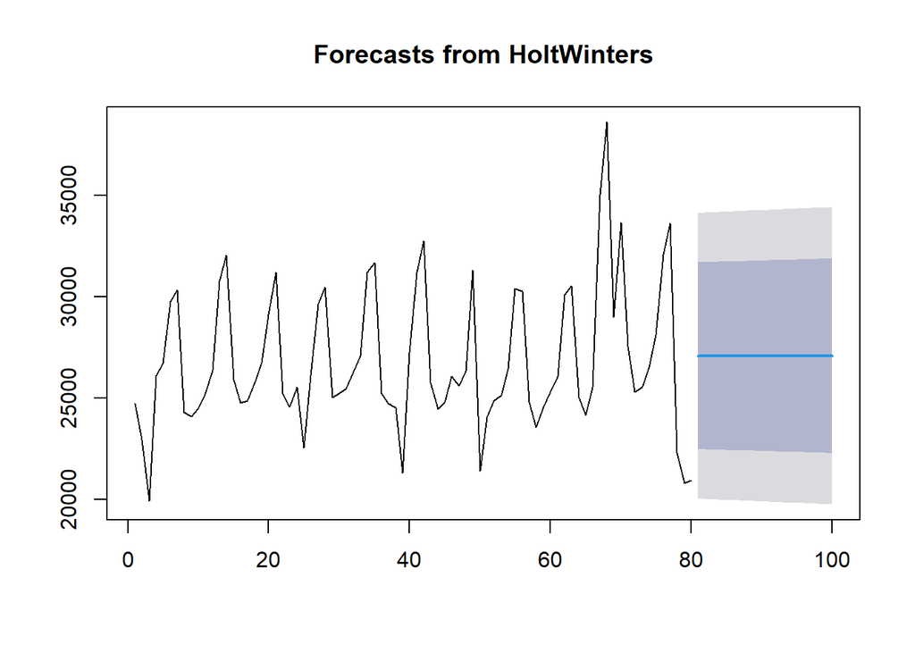

```r
plot(ramalanopt)
```

etelah dilakukan peramalan, akan dilakukan perhitungan keakuratan hasil peramalan. Perhitungan akurasi ini dilakukan baik pada data latih dan data uji.

#### Akurasi Data Latih

Perhitungan akurasi data dapat dilakukan dengan cara langsung maupun manual. Secara langsung, nilai akurasi dapat diambil dari objek yang tersimpan pada hasil SES, yaitu *sum of squared errors* (SSE). Nilai akurasi lain dapat dihitung pula dari nilai SSE tersebut.

```r
#Keakuratan Metode
#Pada data training
SSE1<-ses1$SSE
MSE1<-ses1$SSE/length(train_ma.ts)
RMSE1<-sqrt(MSE1)

akurasi1 <- matrix(c(SSE1,MSE1,RMSE1))
row.names(akurasi1)<- c("SSE", "MSE", "RMSE")
colnames(akurasi1) <- c("Akurasi lamda=0.2")
akurasi1
```

```
##      Akurasi lamda=0.2
## SSE       1.055210e+09
## MSE       1.319013e+07
## RMSE      3.631822e+03
```

```r
SSE2<-ses2$SSE
MSE2<-ses2$SSE/length(train_ma.ts)
RMSE2<-sqrt(MSE2)

akurasi2 <- matrix(c(SSE2,MSE2,RMSE2))
row.names(akurasi2)<- c("SSE", "MSE", "RMSE")
colnames(akurasi2) <- c("Akurasi lamda=0.7")
akurasi2
```

```
##      Akurasi lamda=0.7
## SSE       1.088053e+09
## MSE       1.360067e+07
## RMSE      3.687908e+03
```

```r
#Cara Manual
fitted1<-ramalan1$fitted
sisaan1<-ramalan1$residuals
head(sisaan1)
```

```
## Time Series:
## Start = 1
## End = 6
## Frequency = 1
## [1]        NA -1779.000 -4430.200  2615.840  2723.672  5237.938
```

```r
resid1<-training_ma$Kendaraan-ramalan1$fitted
head(resid1)
```

```
## Time Series:
## Start = 1
## End = 6
## Frequency = 1
## [1]        NA -1779.000 -4430.200  2615.840  2723.672  5237.938
```

```r
#Cara Manual
SSE.1=sum(sisaan1[2:length(train_ma.ts)]^2)
SSE.1
```

```
## [1] 1055210227
```

```r
MSE.1 = SSE.1/length(train_ma.ts)
MSE.1
```

```
## [1] 13190128
```

```r
MAPE.1 = sum(abs(sisaan1[2:length(train_ma.ts)]/train_ma.ts[2:length(train_ma.ts)])*
               100)/length(train_ma.ts)
MAPE.1
```

```
## [1] 10.91856
```

```r
akurasi.1 <- matrix(c(SSE.1,MSE.1,MAPE.1))
row.names(akurasi.1)<- c("SSE", "MSE", "MAPE")
colnames(akurasi.1) <- c("Akurasi lamda=0.2")
akurasi.1
```

```
##      Akurasi lamda=0.2
## SSE       1.055210e+09
## MSE       1.319013e+07
## MAPE      1.091856e+01
```

```r
fitted2<-ramalan2$fitted
sisaan2<-ramalan2$residuals
head(sisaan2)
```

```
## Time Series:
## Start = 1
## End = 6
## Frequency = 1
## [1]        NA -1779.000 -3540.700  5097.790  2160.337  3707.101
```

```r
resid2<-training_ma$Kendaraan-ramalan2$fitted
head(resid2)
```

```
## Time Series:
## Start = 1
## End = 6
## Frequency = 1
## [1]        NA -1779.000 -3540.700  5097.790  2160.337  3707.101
```

```r
#Cara Manual
SSE.2=sum(sisaan2[2:length(train_ma.ts)]^2)
SSE.2
```

```
## [1] 1088053281
```

```r
MSE.2 = SSE.2/length(train_ma.ts)
MSE.2
```

```
## [1] 13600666
```

```r
MAPE.2 = sum(abs(sisaan2[2:length(train_ma.ts)]/train_ma.ts[2:length(train_ma.ts)])*
               100)/length(train_ma.ts)
MAPE.2
```

```
## [1] 10.82897
```

```r
akurasi.2 <- matrix(c(SSE.2,MSE.2,MAPE.2))
row.names(akurasi.2)<- c("SSE", "MSE", "MAPE")
colnames(akurasi.2) <- c("Akurasi lamda=0.2")
akurasi.2
```

```
##      Akurasi lamda=0.2
## SSE       1.088053e+09
## MSE       1.360067e+07
## MAPE      1.082897e+01
```

Akurasi data uji dapat dihitung dengan cara yang hampir sama dengan perhitungan akurasi data latih.

```r
selisih1<-ramalan1$mean-testing_ma$Kendaraan
SSEtesting1<-sum(selisih1^2)
MSEtesting1<-SSEtesting1/length(testing_ma)
MAPEtesting1<-sum(abs(selisih1/testing_ma$Kendaraan)*100)/length(testing_ma$Kendaraan)

selisih2<-ramalan2$mean-testing_ma$Kendaraan
SSEtesting2<-sum(selisih2^2)
MSEtesting2<-SSEtesting2/length(testing_ma)
MAPEtesting2<-sum(abs(selisih2/testing_ma$Kendaraan)*100)/length(testing_ma$Kendaraan)

selisihopt<-ramalanopt$mean-testing_ma$Kendaraan
SSEtestingopt<-sum(selisihopt^2)
MSEtestingopt<-SSEtestingopt/length(testing_ma)
MAPEtestingopt<-sum(abs(selisihopt/testing_ma$Kendaraan)*100)/length(testing_ma$Kendaraan)
```

```r
akurasitesting1 <- matrix(c(SSEtesting1,SSEtesting2,SSEtestingopt))
row.names(akurasitesting1)<- c("SSE1", "SSE2", "SSEopt")
akurasitesting1
```

```
##             [,1]
## SSE1   276521842
## SSE2   894315593
## SSEopt 235703090
```

```r
akurasitesting2 <- matrix(c(MSEtesting1,MSEtesting2,MSEtestingopt))
row.names(akurasitesting2)<- c("MSE1", "MSE2", "MSEopt")
akurasitesting2
```

```
##             [,1]
## MSE1   138260921
## MSE2   447157796
## MSEopt 117851545
```

```r
akurasitesting3 <- matrix(c(MAPEtesting1,MAPEtesting2,MAPEtestingopt))
row.names(akurasitesting3)<- c("MAPE1", "MAPE2", "MAPEopt" )
akurasitesting3
```

```
##              [,1]
## MAPE1    9.478947
## MAPE2   20.360049
## MAPEopt  9.926493
```

Selain dengan cara di atas, perhitungan nilai akurasi dapat menggunakan fungsi `accuracy()` dari *package* `forecast` . Penggunaannya yaitu dengan menuliskan `accuracy(hasil ramalan, kondisi aktual)` . Contohnya adalah sebagai berikut.

```r
#cara lain
accuracy(ramalanopt,testing_ma$Kendaraan)
```

```
##                     ME     RMSE      MAE       MPE      MAPE     MASE      ACF1
## Training set 458.43517 3605.063 2769.554  0.117985 10.100258 1.045864 0.3990214
## Test set     -34.65852 3432.951 2682.863 -1.725342  9.926493 1.013127        NA
```

nilai MAPE untuk ramalan optimum data latih masih di atas 10% namun nilai MAPE untuk data uji sudah dibawah 10%.

# DES

Metode pemulusan *Double Exponential Smoothing* (DES) digunakan untuk data yang memiliki pola tren. Metode DES adalah metode semacam SES, hanya saja dilakukan dua kali, yaitu pertama untuk tahapan ‘level’ dan kedua untuk tahapan ‘tren’. Pemulusan menggunakan metode ini akan menghasilkan peramalan tidak konstan untuk periode berikutnya.

Pemulusan dengan metode DES kali ini akan menggunakan fungsi `HoltWinters()` . Jika sebelumnya nilai argumen `beta` dibuat `FALSE` , kali ini argumen tersebut akan diinisialisasi bersamaan dengan nilai `alpha` .

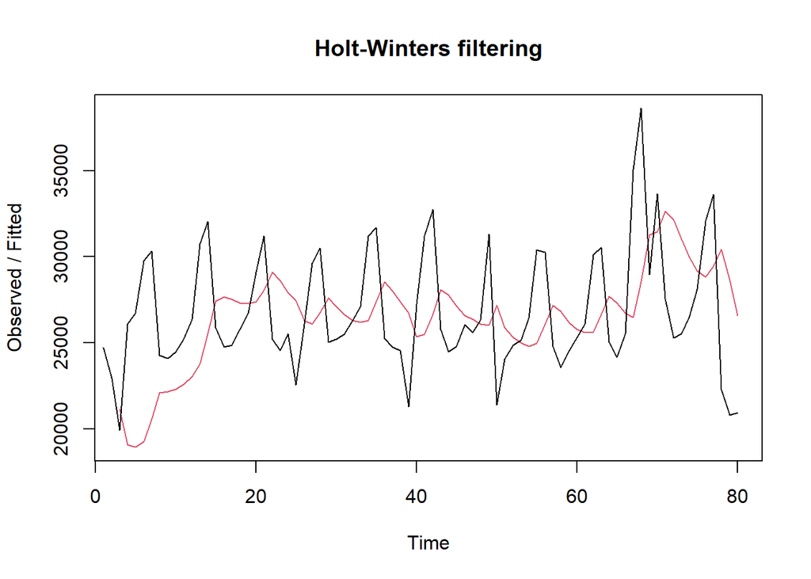

```r
#Lamda=0.2 dan gamma=0.2
des.1<- HoltWinters(train_ma.ts, gamma = FALSE, beta = 0.2, alpha = 0.2)
plot(des.1)
```

```r
#ramalan
ramalandes1 <- forecast::forecast(des.1, h = 20)
ramalandes1
```

```
##     Point Forecast     Lo 80    Hi 80       Lo 95    Hi 95
##  81       24747.86 19204.895 30290.82  16270.6286 33225.09
##  82       24035.21 18334.843 29735.57  15317.2518 32753.16
##  83       23322.56 17414.685 29230.43  14287.2461 32357.87
##  84       22609.91 16441.508 28778.30  13176.1555 32043.66
##  85       21897.26 15414.122 28380.39  11982.1586 31812.35
##  86       21184.61 14332.822 28036.39  10705.7076 31663.50
##  87       20471.95 13199.048 27744.86   9349.0031 31594.91
##  88       19759.30 12015.010 27503.60   7915.4289 31603.18
##  89       19046.65 10783.363 27309.94   6409.0412 31684.27
##  90       18334.00  9506.934 27161.07   4834.1656 31833.84
##  91       17621.35  8188.540 27054.16   3195.1112 32047.59
##  92       16908.70  6830.871 26986.53   1495.9900 32321.41
##  93       16196.05  5436.421 26955.68   -259.3832 32651.49
##  94       15483.40  4007.461 26959.34  -2067.5342 33034.34
##  95       14770.75  2546.037 26995.46  -3925.3355 33466.84
##  96       14058.10  1053.975 27062.22  -5829.9923 33946.19
##  97       13345.45  -467.096 27158.00  -7779.0159 34469.92
##  98       12632.80 -2015.730 27281.33  -9770.1933 35035.79
##  99       11920.15 -3590.640 27430.94 -11801.5558 35641.85
## 100       11207.50 -5190.679 27605.67 -13871.3492 36286.35
```

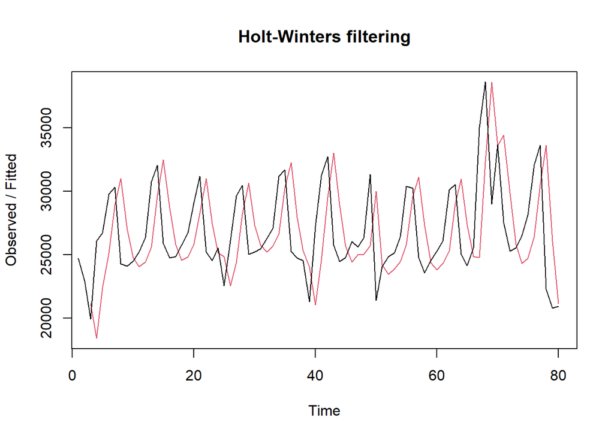

```r
#Lamda=0.6 dan gamma=0.3
des.2<- HoltWinters(train_ma.ts, gamma = FALSE, beta = 0.3, alpha = 0.6)
plot(des.2)
```

```r
#ramalan
ramalandes2 <- forecast::forecast(des.2, h = 20)
ramalandes2
```

```
##     Point Forecast       Lo 80    Hi 80       Lo 95    Hi 95
##  81      19263.793  13689.9033 24837.68   10739.264 27788.32
##  82      17491.539  10422.5809 24560.50    6680.501 28302.58
##  83      15719.285   6853.4706 24585.10    2160.192 29278.38
##  84      13947.031   3039.2834 24854.78   -2734.929 30628.99
##  85      12174.776   -982.4366 25331.99   -7947.444 32297.00
##  86      10402.522  -5186.4418 25991.49  -13438.741 34243.79
##  87       8630.268  -9554.9679 26815.50  -19181.650 36442.19
##  88       6858.014 -14074.8908 27790.92  -25156.101 38872.13
##  89       5085.760 -18736.0810 28907.60  -31346.602 41518.12
##  90       3313.506 -23530.4290 30157.44  -37740.750 44367.76
##  91       1541.252 -28451.2460 31533.75  -44328.315 47410.82
##  92       -231.002 -33492.8811 33030.88  -51100.656 50638.65
##  93      -2003.256 -38650.4668 34643.95  -58050.328 54043.82
##  94      -3775.510 -43919.7442 36368.72  -65170.818 57619.80
##  95      -5547.764 -49296.9384 38201.41  -72456.352 61360.82
##  96      -7320.018 -54778.6679 40138.63  -79901.759 65261.72
##  97      -9092.272 -60361.8762 42177.33  -87502.365 69317.82
##  98     -10864.526 -66043.7803 44314.73  -95253.913 73524.86
##  99     -12636.780 -71821.8289 46548.27 -103152.501 77878.94
## 100     -14409.035 -77693.6710 48875.60 -111194.534 82376.46
```

Selanjutnya jika ingin membandingkan plot data latih dan data uji adalah sebagai berikut.

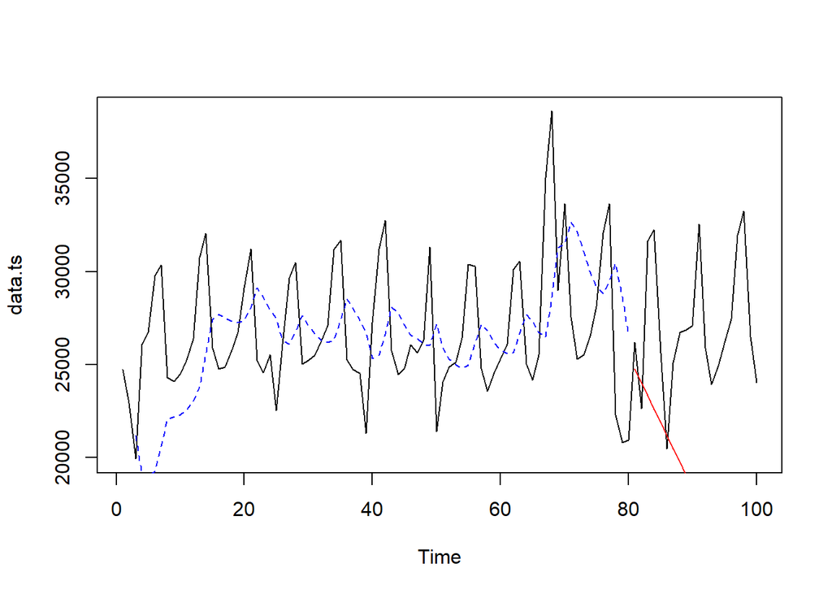

```r
#Visually evaluate the prediction
plot(data.ts)
lines(des.1$fitted[,1], lty=2, col="blue")
lines(ramalandes1$mean, col="red")
```

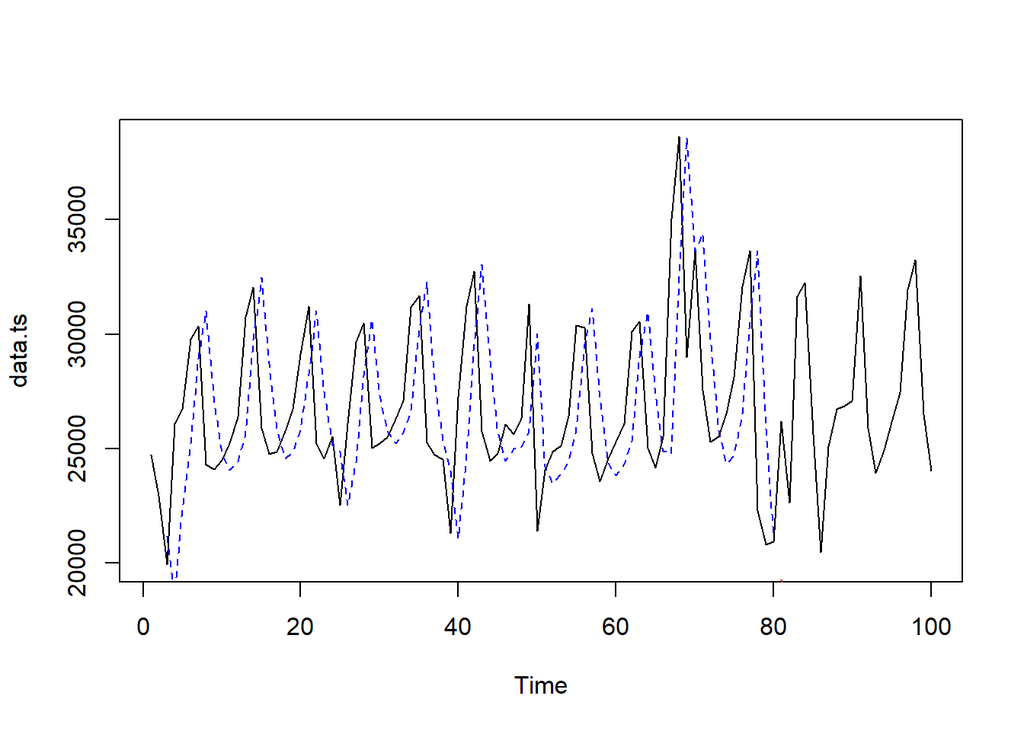

```r
plot(data.ts)
lines(des.2$fitted[,1], lty=2, col="blue")
lines(ramalandes2$mean, col="red")
```

Untuk mendapatkan nilai parameter optimum dari DES, argumen `alpha` dan `beta` dapat dibuat `NULL` seperti berikut.

```r
#Lamda dan gamma optimum
des.opt<- HoltWinters(train_ma.ts, gamma = FALSE)
des.opt
```

```
## Holt-Winters exponential smoothing with trend and without seasonal component.
##
## Call:
## HoltWinters(x = train_ma.ts, gamma = FALSE)
##
## Smoothing parameters:
##  alpha: 0.9543303
##  beta : 0.03954566
##  gamma: FALSE
##
## Coefficients:
##         [,1]
## a 20926.4469
## b  -324.3333
```

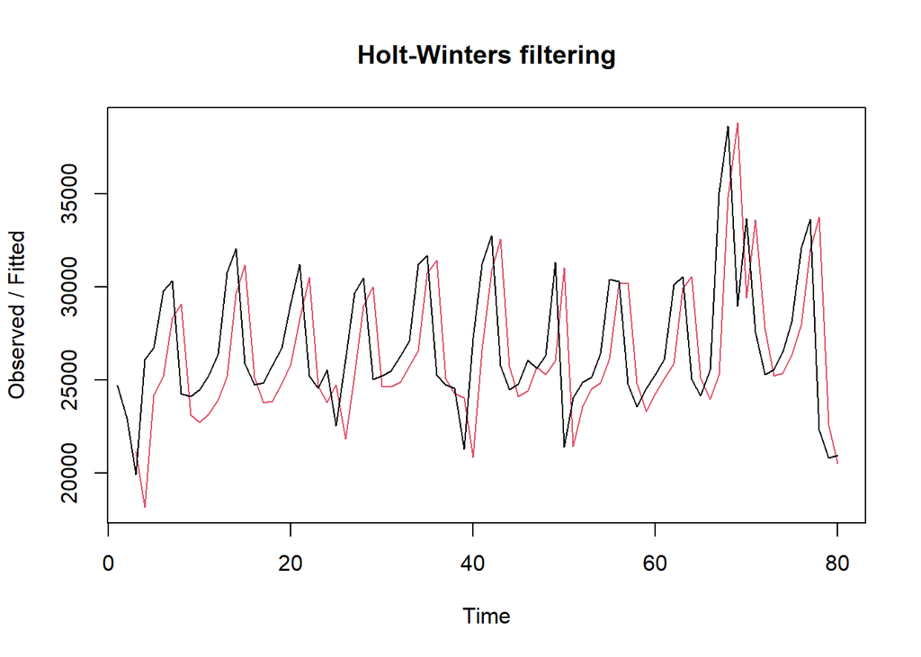

```r
plot(des.opt)
```

```r
#ramalan
ramalandesopt <- forecast::forecast(des.opt, h = 20)
ramalandesopt
```

```
##     Point Forecast       Lo 80    Hi 80       Lo 95    Hi 95
##  81       20602.11  15632.8043 25571.42  13002.2109 28202.02
##  82       20277.78  13277.9252 27277.64   9572.4257 30983.13
##  83       19953.45  11282.4501 28624.44   6692.3017 33214.59
##  84       19629.11   9464.0253 29794.20   4082.9527 35175.27
##  85       19304.78   7750.6981 30858.86   1634.3364 36975.22
##  86       18980.45   6105.6686 31855.23   -709.8273 38670.72
##  87       18656.11   4507.3093 32804.92  -2982.6154 40294.84
##  88       18331.78   2941.7380 33721.82  -5205.2584 41868.82
##  89       18007.45   1399.4828 34615.41  -7392.2424 43407.14
##  90       17683.11   -126.2158 35492.44  -9553.9054 44920.13
##  91       17358.78  -1640.3506 36357.91 -11697.8831 46415.44
##  92       17034.45  -3146.7100 37215.60 -13829.9693 47898.86
##  93       16710.11  -4648.2318 38068.46 -15954.6570 49374.88
##  94       16385.78  -6147.2351 38918.80 -18075.4930 50847.05
##  95       16061.45  -7645.5780 39768.47 -20195.3191 52318.21
##  96       15737.11  -9144.7676 40619.00 -22316.4401 53790.67
##  97       15412.78 -10646.0391 41471.60 -24440.7449 55266.31
##  98       15088.45 -12150.4137 42327.31 -26569.7957 56746.69
##  99       14764.11 -13658.7425 43186.97 -28704.8939 58233.12
## 100       14439.78 -15171.7389 44051.30 -30847.1306 59726.69
```

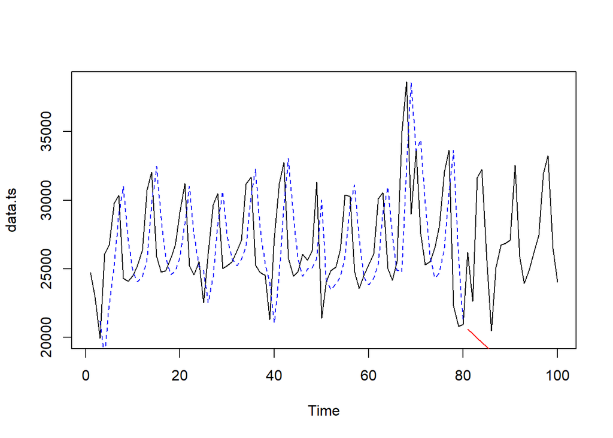

```r
plot(data.ts)
lines(des.2$fitted[,1], lty=2, col="blue")
lines(ramalandesopt$mean, col="red")
```

Selanjutnya akan dilakukan perhitungan akurasi pada data latih maupun data uji dengan ukuran akurasi SSE, MSE dan MAPE.

#### Akurasi Data Latih

```r
#Akurasi Data Training
ssedes.train1<-des.1$SSE
msedes.train1<-ssedes.train1/length(train_ma.ts)
sisaandes1<-ramalandes1$residuals
head(sisaandes1)
```

```
## Time Series:
## Start = 1
## End = 6
## Frequency = 1
## [1]        NA        NA -1228.000  7005.720  7783.467 10522.326
```

```r
mapedes.train1 <- sum(abs(sisaandes1[3:length(train_ma.ts)]/train_ma.ts[3:length(train_ma.ts)])
                      *100)/length(train_ma.ts)

ssedes.train2<-des.2$SSE
msedes.train2<-ssedes.train2/length(train_ma.ts)
sisaandes2<-ramalandes2$residuals
head(sisaandes2)
```

```
## Time Series:
## Start = 1
## End = 6
## Frequency = 1
## [1]        NA        NA -1228.000  7668.840  4318.185  4628.649
```

```r
mapedes.train2 <- sum(abs(sisaandes2[3:length(train_ma.ts)]/train_ma.ts[3:length(train_ma.ts)])
                      *100)/length(train_ma.ts)
```

```r
akurasides.1 <- matrix(c(ssedes.train1,msedes.train1,mapedes.train1))
row.names(akurasides.1)<- c("SSE", "MSE", "MAPE")
colnames(akurasides.1) <- c("Akurasi lamda=0.2 dan gamma=0.2")
akurasides.1
```

```
##      Akurasi lamda=0.2 dan gamma=0.2
## SSE                     1.449575e+09
## MSE                     1.811969e+07
## MAPE                    1.270948e+01
```

```r
akurasides.2 <- matrix(c(ssedes.train2,msedes.train2,mapedes.train2))
row.names(akurasides.2)<- c("SSE", "MSE", "MAPE")
colnames(akurasides.2) <- c("Akurasi lamda=0.6 dan gamma=0.3")
akurasides.2
```

```
##      Akurasi lamda=0.6 dan gamma=0.3
## SSE                     1.456583e+09
## MSE                     1.820729e+07
## MAPE                    1.255140e+01
```

#### Akurasi Data Uji

```r
#Akurasi Data Testing
selisihdes1<-ramalandes1$mean-testing_ma$Kendaraan
selisihdes1
```

```
## Time Series:
## Start = 81
## End = 100
## Frequency = 1
##  [1]  -1434.1424   1402.2071  -8318.4434  -9620.0939  -3716.7444    701.6051
##  [7]  -4634.0454  -6979.6959  -7810.3464  -8741.9969 -14911.6474  -8973.2979
## [13]  -7739.9484  -9445.5989 -11396.2494 -13385.8999 -18592.5504 -20619.2009
## [19] -14578.8514 -12811.5019
```

```r
SSEtestingdes1<-sum(selisihdes1^2)
MSEtestingdes1<-SSEtestingdes1/length(testing_ma$Kendaraan)
MAPEtestingdes1<-sum(abs(selisihdes1/testing_ma$Kendaraan)*100)/length(testing_ma$Kendaraan)

selisihdes2<-ramalandes2$mean-testing_ma$Kendaraan
selisihdes2
```

```
## Time Series:
## Start = 81
## End = 100
## Frequency = 1
##  [1]  -6918.207  -5141.461 -15921.715 -18282.969 -13439.224 -10080.478
##  [7] -16475.732 -19880.986 -21771.240 -23762.494 -30991.748 -26113.002
## [13] -25939.256 -28704.510 -31714.764 -34764.018 -41030.272 -44116.526
## [19] -39135.780 -38428.035
```

```r
SSEtestingdes2<-sum(selisihdes2^2)
MSEtestingdes2<-SSEtestingdes2/length(testing_ma$Kendaraan)
MAPEtestingdes2<-sum(abs(selisihdes2/testing_ma$Kendaraan)*100)/length(testing_ma$Kendaraan)

selisihdesopt<-ramalandesopt$mean-testing_ma$Kendaraan
selisihdesopt
```

```
## Time Series:
## Start = 81
## End = 100
## Frequency = 1
##  [1]  -5579.886  -2355.220 -11687.553 -12600.886  -6309.220  -1502.553
##  [7]  -6449.886  -8407.220  -8849.553  -9392.886 -15174.220  -8847.553
## [13]  -7225.886  -8543.219 -10105.553 -11706.886 -16525.219 -18163.553
## [19] -11734.886  -9579.219
```

```r
SSEtestingdesopt<-sum(selisihdesopt^2)
MSEtestingdesopt<-SSEtestingdesopt/length(testing_ma$Kendaraan)
MAPEtestingdesopt<-sum(abs(selisihdesopt/testing_ma$Kendaraan)*100)/length(testing_ma$Kendaraan)

akurasitestingdes <-
  matrix(c(SSEtestingdes1,MSEtestingdes1,MAPEtestingdes1,SSEtestingdes2,MSEtestingdes2,
           MAPEtestingdes2,SSEtestingdesopt,MSEtestingdesopt,MAPEtestingdesopt),
         nrow=3,ncol=3)
row.names(akurasitestingdes)<- c("SSE", "MSE", "MAPE")
colnames(akurasitestingdes) <- c("des ske1","des ske2","des opt")
akurasitestingdes
```

```
##          des ske1     des ske2      des opt
## SSE  2.296259e+09 1.464125e+10 2.158327e+09
## MSE  1.148129e+08 7.320624e+08 1.079163e+08
## MAPE 3.316571e+01 9.015171e+01 3.407940e+01
```

nilai MAPE untuk ketiga metode dalam SES masih sangat besar (>10%), selain itu nilai SSE dan MSE untuk ketiga metode tersebut juga masih sangat tinggi sehingga metode DES kurang tepat digunakan untuk data tersebut.

# Perbandingan SES dan DES

```r
MSEfull <-
  matrix(c(MSEtesting1,MSEtesting2,MSEtestingopt,MSEtestingdes1,MSEtestingdes2,
           MSEtestingdesopt),nrow=3,ncol=2)
row.names(MSEfull)<- c("ske 1", "ske 2", "ske opt")
colnames(MSEfull) <- c("SES","DES")
MSEfull
```

```
##               SES       DES
## ske 1   138260921 114812939
## ske 2   447157796 732062403
## ske opt 117851545 107916333
```

Kedua metode dapat dibandingkan dengan menggunakan ukuran akurasi yang sama. Contoh di atas adalah perbandingan kedua metode dengan ukuran akurasi MSE. Hasilnya didapatkan metode DES lebih baik dibandingkan metode SES dilihat dari MSE yang lebih kecil nilainya.

```r
#membagi data menjadi training dan testing
training<-data[1:80,2]
testing<-data[81:100,2]
training.ts<-ts(training, frequency = 7)
testing.ts<-ts(testing, frequency = 7)
```

Kemudian akan dilakukan eskplorasi dengan plot data deret waktu sebagai berikut.

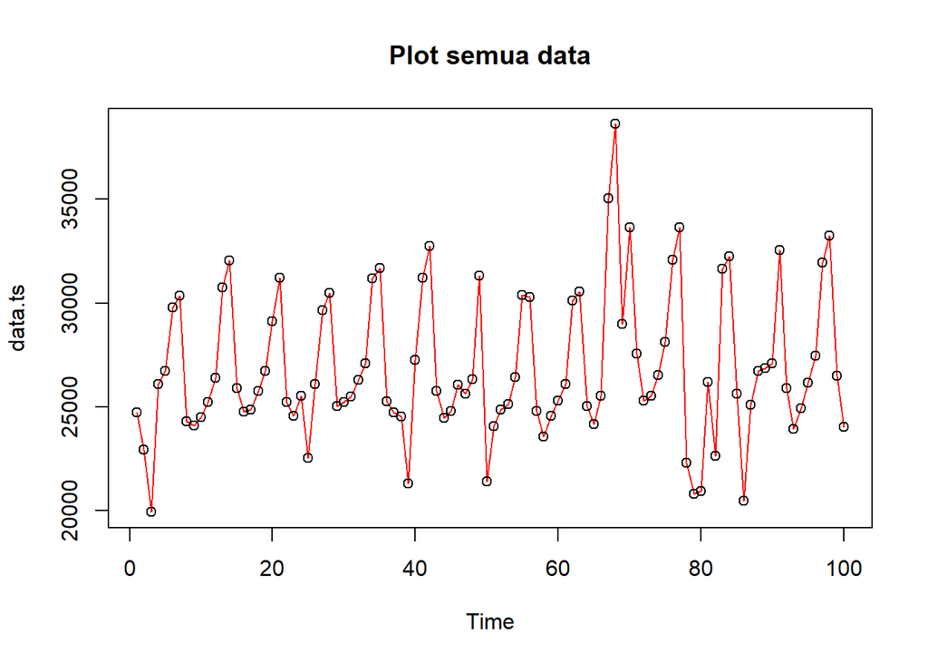

```r
#Membuat plot time series
plot(data.ts, col="red",main="Plot semua data")
points(data.ts)
```

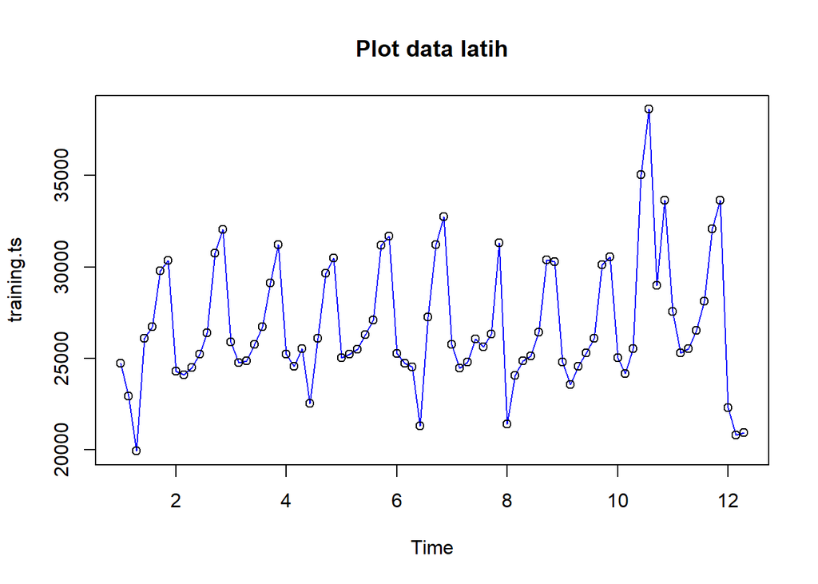

```r
plot(training.ts, col="blue",main="Plot data latih")
points(training.ts)
```

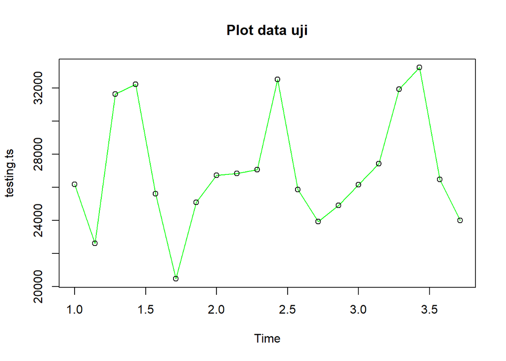

```r
plot(testing.ts, col="green",main="Plot data uji")
points(testing.ts)
```

Pemulusan data musiman dengan metode Winter dilakukan menggunakan fungsi `HoltWinters()` dengan memasukkan argumen tambahan, yaitu `gamma()` dan `seasonal()` . Arguman `seasonal()` diinisialisasi menyesuaikan jenis musiman, aditif atau multiplikatif.

# Winter Aditif

Perhitungan dengan model aditif dilakukan jika plot data asli menunjukkan fluktuasi musiman yang relatif stabil (konstan).

#### Pemulusan

```r
#Pemulusan dengan winter aditif
winter1 <- HoltWinters(training.ts,alpha=0.2,beta=0.1,gamma=0.1,seasonal = "additive")
winter1$fitted
```

```
## Time Series:
## Start = c(2, 1)
## End = c(12, 3)
## Frequency = 7
##               xhat    level        trend     season
##  2.000000 23380.93 25609.09  142.9608844 -2371.1224
##  2.142857 23597.77 25932.46  161.0023810 -2495.6939
##  2.285714 24113.32 26195.91  171.2469592 -2253.8367
##  2.428571 25768.88 26442.89  178.8205397  -852.8367
##  2.571429 27441.92 26511.14  167.7629934   763.0204
##  2.714286 30269.02 26467.52  146.6245536  3654.8776
##  2.857143 30425.25 26713.14  156.5241678  3555.5918
##  3.000000 25085.55 27195.41  189.0990901 -2298.9565
##  3.142857 25296.97 27546.40  205.2880121 -2454.7156
##  3.285714 25615.30 27644.29  194.5485715 -2223.5424
##  3.428571 26972.14 27689.58  179.6225846  -897.0669
##  3.571429 28463.48 27629.38  155.6398335   678.4666
##  3.714286 31255.09 27439.52  121.0901646  3694.4760
##  3.857143 30897.43 27133.19   78.3484390  3685.8915
##  4.000000 25122.91 27272.65   84.4597794 -2234.2008
##  4.142857 24965.04 27376.33   86.3815021 -2497.6733
##  4.285714 25175.86 27380.91   78.2007013 -2283.2464
##  4.428571 26623.54 27531.13   85.4035073  -992.9979
##  4.571429 27346.03 26801.83    3.9327132   540.2680
##  4.714286 30060.84 26558.16  -20.8278943  3523.5091
##  4.857143 30135.35 26454.16  -29.1446450  3710.3369
##  5.000000 24247.16 26495.75  -22.0717084 -2226.5139
##  5.142857 24093.21 26630.04   -6.4349094 -2530.3965
##  5.285714 24612.39 26850.56   16.2608808 -2254.4351
##  5.428571 25755.08 27040.35   33.6130675 -1318.8811
##  5.571429 27668.46 27182.74   44.4914748   441.2255
##  5.714286 30635.15 27111.94   32.9622383  3490.2421
##  5.857143 31039.88 27257.08   44.1792731  3738.6286
##  6.000000 25324.71 27431.48   57.2015849 -2163.9667
##  6.142857 25089.17 27473.14   55.6473091 -2439.6134
##  6.285714 25323.69 27459.95   48.7638758 -2185.0264
##  6.428571 26110.58 27352.78   33.1701121 -1275.3675
##  6.571429 26754.80 26422.83  -63.1414794   395.1086
##  6.714286 29940.82 26458.93  -53.2174445  3535.1102
##  6.857143 30422.87 26659.95  -27.7939005  3790.7179
```

[output cut: 23 more lines]

```
## 10.285714 24513.11 26601.99   19.3329510 -2108.2155
## 10.428571 25356.79 26825.70   39.7708165 -1508.6817
## 10.571429 29259.69 28802.91  233.5150153   223.2581
## 10.714286 34750.70 30907.89  420.6612784  3422.1458
## 10.857143 34571.70 30174.61  305.2673102  4091.8151
## 11.000000 28412.13 30296.54  286.9334019 -2171.3467
## 11.142857 28239.67 30413.25  269.9108447 -2443.4868
## 11.285714 28279.22 30094.63  211.0573829 -2026.4641
## 11.428571 29179.31 29756.84  156.1730118  -733.7049
## 11.571429 30455.54 29380.75  102.9468707   971.8432
## 11.714286 32035.38 29018.39   56.4160597  2960.5699
## 11.857143 33159.74 29083.93   57.3285550  4018.4795
## 12.000000 27064.59 29237.11   66.9137879 -2239.4370
## 12.142857 25646.25 28353.31  -28.1579721 -2678.9006
## 12.285714 24984.38 27355.50 -125.1229476 -2246.0016
```

```r
xhat1 <- winter1$fitted[,2]

winter1.opt<- HoltWinters(training.ts, alpha= NULL,  beta = NULL, gamma = NULL, seasonal = "additive")
winter1.opt
```

```
## Holt-Winters exponential smoothing with trend and additive seasonal component.
##
## Call:
## HoltWinters(x = training.ts, alpha = NULL, beta = NULL, gamma = NULL,     seasonal = "additive")
##
## Smoothing parameters:
##  alpha: 0.4003049
##  beta : 0.01256664
##  gamma: 0
##
## Coefficients:
##          [,1]
## a  24756.2250
## b     32.9157
## s1  -852.8367
## s2   763.0204
## s3  3654.8776
## s4  3555.5918
## s5 -2371.1224
## s6 -2495.6939
## s7 -2253.8367
```

```r
winter1.opt$fitted
```

```
## Time Series:
## Start = c(2, 1)
## End = c(12, 3)
## Frequency = 7
##               xhat    level     trend     season
##  2.000000 23380.93 25609.09 142.96088 -2371.1224
##  2.142857 23764.96 26113.15 147.49876 -2495.6939
##  2.285714 24294.17 26398.77 149.23449 -2253.8367
##  2.428571 25924.59 26627.20 150.22967  -852.8367
##  2.571429 27403.46 26493.78 146.66510   763.0204
##  2.714286 30029.17 26232.75 141.54174  3654.8776
##  2.857143 30369.28 26668.45 145.23832  3555.5918
##  3.000000 25270.68 27488.09 153.71330 -2371.1224
##  3.142857 25552.88 27891.72 156.85394 -2495.6939
##  3.285714 25630.21 27731.18 152.86537 -2253.8367
##  3.428571 26875.53 27579.33 149.03612  -852.8367
##  3.571429 28193.53 27287.02 143.48986   763.0204
##  3.714286 30638.09 26847.05 136.15778  3654.8776
##  3.857143 30058.81 26374.71 128.51100  3555.5918
##  4.000000 24724.39 26961.25 134.26681 -2371.1224
##  4.142857 24934.57 27293.51 136.75494 -2495.6939
##  4.285714 25159.73 27278.72 134.85056 -2253.8367
##  4.428571 26848.10 27564.19 136.74336  -852.8367
##  4.571429 26858.53 25980.39 115.12183   763.0204
##  4.714286 29561.29 25795.07 111.34631  3654.8776
##  4.857143 29607.28 25939.92 111.76741  3555.5918
##  5.000000 24149.73 26404.65 116.20288 -2371.1224
##  5.142857 24497.76 26872.83 120.62606 -2495.6939
##  5.285714 25156.23 27285.77 124.29953 -2253.8367
##  5.428571 26812.77 27539.68 125.92823  -852.8367
##  5.571429 28346.30 27459.94 123.34372   763.0204
##  5.714286 30853.09 27081.18 117.03396  3654.8776
##  5.857143 31009.83 27335.48 118.75896  3555.5918
##  6.000000 25477.98 27726.92 122.18556 -2371.1224
##  6.142857 25381.97 27756.64 121.02362 -2495.6939
##  6.285714 25486.66 27622.68 117.81936 -2253.8367
##  6.428571 26623.39 27363.15 113.07730  -852.8367
##  6.571429 26192.54 25343.25  86.27291   763.0204
##  6.714286 29599.70 25853.23  91.59749  3654.8776
##  6.857143 30245.53 26590.23  99.70814  3555.5918
```

[output cut: 23 more lines]

```
## 10.285714 24721.42 26897.65  77.61226 -2253.8367
## 10.428571 26529.81 27300.94  81.70494  -852.8367
## 10.571429 31678.47 30790.92 124.53548   763.0204
## 10.714286 37507.30 33692.98 159.43966  3654.8776
## 10.857143 34111.44 30439.30 116.54823  3555.5918
## 11.000000 28116.26 30373.13 114.25211 -2371.1224
## 11.142857 27880.88 30265.11 111.45886 -2495.6939
## 11.285714 27186.86 29342.23  98.46070 -2253.8367
## 11.428571 28016.76 28779.45  90.15106  -852.8367
## 11.571429 29115.27 28269.64  82.61157   763.0204
## 11.714286 31689.97 27957.44  77.65016  3654.8776
## 11.857143 31826.83 28191.62  79.61724  3555.5918
## 12.000000 26714.27 28996.66  88.73333 -2371.1224
## 12.142857 24893.63 27322.74  66.58273 -2495.6939
## 12.285714 23541.97 25749.82  45.97971 -2253.8367
```

```r
xhat1.opt <- winter1.opt$fitted[,2]
```

#### Peramalan

```r
#Forecast
forecast1 <- predict(winter1, n.ahead = 20)
forecast1.opt <- predict(winter1.opt, n.ahead = 20)
```

#### Plot Deret Waktu

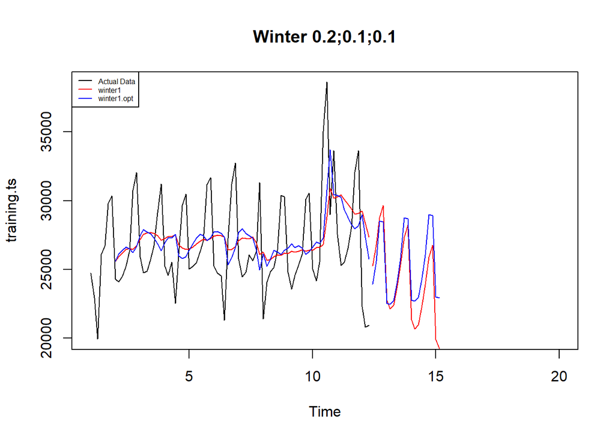

```r
#Plot time series
plot(training.ts,main="Winter 0.2;0.1;0.1",type="l",col="black",
     xlim=c(1,20),pch=12)
lines(xhat1,type="l",col="red")
lines(xhat1.opt,type="l",col="blue")
lines(forecast1,type="l",col="red")
lines(forecast1.opt,type="l",col="blue")
legend("topleft",c("Actual Data",expression(paste(winter1)),
                   expression(paste(winter1.opt))),cex=0.5,
       col=c("black","red","blue"),lty=1)
```

#### Akurasi Data Latih

```r
#Akurasi data training
SSE1<-winter1$SSE
MSE1<-winter1$SSE/length(training.ts)
RMSE1<-sqrt(MSE1)
fitted_values <- winter1$fitted[,1]
abs_error <- abs(training.ts - fitted_values)
MAPE1 <- mean(abs_error / training.ts * 100)

akurasi1 <- matrix(c(SSE1,MSE1,RMSE1))
row.names(akurasi1)<- c("SSE", "MSE", "RMSE")
colnames(akurasi1) <- c("Akurasi")
akurasi1
```

```
##           Akurasi
## SSE  419766100.22
## MSE    5247076.25
## RMSE      2290.65
```

```r
SSE1.opt<-winter1.opt$SSE
MSE1.opt<-winter1.opt$SSE/length(training.ts)
RMSE1.opt<-sqrt(MSE1.opt)
fitted_values <- winter1.opt$fitted[,1]
abs_error <- abs(training.ts - fitted_values)
MAPE1.opt <- mean(abs_error / training.ts * 100)
akurasi1.opt <- matrix(c(SSE1.opt,MSE1.opt,RMSE1.opt,MAPE1.opt))
row.names(akurasi1.opt)<- c("SSE1.opt", "MSE1.opt", "RMSE1.opt", "MAPE1.opt")
colnames(akurasi1.opt) <- c("Akurasi")
akurasi1.opt
```

```
##                Akurasi
## SSE1.opt  3.768364e+08
## MSE1.opt  4.710455e+06
## RMSE1.opt 2.170358e+03
## MAPE1.opt 5.493249e+00
```

```r
akurasi1.train = data.frame(Model_Winter = c("Winter 1","Winter1 optimal"),
                            Nilai_SSE=c(SSE1,SSE1.opt),
                            Nilai_MSE=c(MSE1,MSE1.opt),Nilai_RMSE=c(RMSE1,RMSE1.opt),Nilai_MAPE=c(MAPE1,MAPE1.opt))
akurasi1.train
```

```
##      Model_Winter Nilai_SSE Nilai_MSE Nilai_RMSE Nilai_MAPE
## 1        Winter 1 419766100   5247076   2290.650   5.592465
## 2 Winter1 optimal 376836412   4710455   2170.358   5.493249
```

Hasil analisis menggunakan Winter aditif dengan nilai alpha, beta, dan gamma optimum menghasilkan nilai SSE, MSE, dan RMSE yang lebih kecil. Selain itu nilai MAPE juga lebih kecil serta dibawah 10% yang menandakan bahwa nilai ini dapat dikategorikan sebagai nilai akurasi yang sangat baik.

#### Akurasi Data Uji

```r
#Akurasi Data Testing
forecast1<-data.frame(forecast1)
testing.ts<-data.frame(testing.ts)
selisih1<-forecast1-testing.ts
SSEtesting1<-sum(selisih1^2)
MSEtesting1<-SSEtesting1/length(testing.ts)

forecast1.opt<-data.frame(forecast1.opt)
selisih1.opt<-forecast1.opt-testing.ts
SSEtesting1.opt<-sum(selisih1.opt^2)
MSEtesting1.opt<-SSEtesting1.opt/length(testing.ts)


akurasi1.test = data.frame(Model_Winter = c("Winter 1","Winter1 optimal"),
                            Nilai_SSE=c(SSEtesting1,SSEtesting1.opt),
                            Nilai_MSE=c(MSEtesting1,MSEtesting1.opt))
akurasi1.test
```

```
##      Model_Winter Nilai_SSE Nilai_MSE
## 1        Winter 1 299358807 299358807
## 2 Winter1 optimal 143403777 143403777
```

# Winter Multiplikatif

Model multiplikatif digunakan cocok digunakan jika plot data asli menunjukkan fluktuasi musiman yang bervariasi.

#### Pemulusan

```r
#Pemulusan dengan winter multiplikatif
winter2 <- HoltWinters(training.ts,alpha=0.2,beta=0.1,gamma=0.3,seasonal = "multiplicative")
winter2$fitted
```

```
## Time Series:
## Start = c(2, 1)
## End = c(12, 3)
## Frequency = 7
##               xhat    level        trend    season
##  2.000000 23448.07 25609.09  142.9608844 0.9105324
##  2.142857 23635.97 25935.44  161.3001564 0.9057057
##  2.285714 24136.54 26201.42  171.7678865 0.9151923
##  2.428571 25777.34 26450.87  179.5359413 0.9679667
##  2.571429 27457.73 26514.42  167.9375785 1.0290594
##  2.714286 30333.23 26473.87  147.0888504 1.1394494
##  2.857143 30398.10 26696.57  154.6497835 1.1320941
##  3.000000 25093.86 27143.75  183.9034619 0.9182586
##  3.142857 25211.51 27502.15  201.3526429 0.9100477
##  3.285714 25528.06 27604.27  191.4298938 0.9184176
##  3.428571 26796.39 27652.18  177.0777475 0.9628856
##  3.571429 28309.48 27616.69  155.8209485 1.0193345
##  3.714286 31542.81 27463.79  124.9482337 1.1433220
##  3.857143 31245.21 27164.57   82.5313815 1.1467352
##  4.000000 25279.24 27239.74   81.7952749 0.9252499
##  4.142857 24817.78 27308.51   80.4930641 0.9061222
##  4.285714 25013.33 27331.22   74.7149824 0.9126974
##  4.428571 26336.51 27520.47   86.1683451 0.9539919
##  4.571429 26969.37 26812.81    6.7859302 1.0055842
##  4.714286 29885.07 26648.28  -10.3457305 1.1218987
##  4.857143 30470.93 26595.14  -14.6254074 1.1463634
##  5.000000 24569.23 26583.67  -14.3101369 0.9247204
##  5.142857 24099.94 26668.80   -4.3661233 0.9038234
##  5.285714 24705.95 26914.05   20.5958664 0.9172555
##  5.428571 24972.31 27103.42   37.4732841 0.9200991
##  5.571429 27435.83 27429.27   66.3112173 0.9978266
##  5.714286 30777.06 27426.67   59.4197179 1.1197323
##  5.857143 31676.03 27560.92   66.9025189 1.1465265
##  6.000000 25727.14 27630.43   67.1636665 0.9288580
##  6.142857 25269.81 27594.21   56.8254833 0.9138827
##  6.285714 25488.36 27536.19   45.3402886 0.9241097
##  6.428571 25530.69 27377.15   24.9020813 0.9317073
##  6.571429 26289.85 26492.82  -66.0210649 0.9948179
##  6.714286 29851.96 26620.03  -46.6979086 1.1233804
##  6.857143 30722.34 26815.46  -22.4845092 1.1466565
```

[output cut: 23 more lines]

```
## 10.285714 24867.17 26800.73   16.8307278 0.9272720
## 10.428571 25127.51 26961.60   31.2349664 0.9308955
## 10.571429 28993.24 29123.36  244.2877269 0.9872510
## 10.714286 35375.56 31317.26  439.2484379 1.1139625
## 10.857143 35805.97 30608.43  324.4410638 1.1575380
## 11.000000 28282.68 30561.23  287.2764211 0.9168250
## 11.142857 28024.38 30691.07  271.5334521 0.9051041
## 11.285714 28529.56 30359.94  211.2667661 0.9332167
## 11.428571 30455.95 29929.43  147.0896189 1.0126154
## 11.571429 31159.59 29298.75   69.3117992 1.0610028
## 11.714286 30647.65 28796.79   12.1848992 1.0638230
## 11.857143 33212.85 29078.44   39.1321120 1.1406462
## 12.000000 26641.95 29192.30   46.6041226 0.9111816
## 12.142857 24951.12 28288.28  -48.4581213 0.8835437
## 12.285714 24691.47 27299.72 -142.4685615 0.9092037
```

```r
xhat2 <- winter2$fitted[,2]

winter2.opt<- HoltWinters(training.ts, alpha= NULL,  beta = NULL, gamma = NULL, seasonal = "multiplicative")
winter2.opt$fitted
```

```
## Time Series:
## Start = c(2, 1)
## End = c(12, 3)
## Frequency = 7
##               xhat    level     trend    season
##  2.000000 23448.07 25609.09 142.96088 0.9105324
##  2.142857 23720.72 26042.76 147.56348 0.9057057
##  2.285714 24230.91 26326.59 149.72083 0.9151923
##  2.428571 25862.04 26566.75 151.15275 0.9679667
##  2.571429 27428.66 26506.31 147.80271 1.0290594
##  2.714286 30167.25 26332.57 142.71210 1.1394494
##  2.857143 30325.03 26641.32 145.34084 1.1320941
##  3.000000 24970.32 27270.86 153.00662 0.9105324
##  3.142857 25272.75 27745.83 158.10401 0.9057057
##  3.285714 25515.30 27724.45 155.26237 0.9151923
##  3.428571 26916.77 27655.82 151.71775 0.9679667
##  3.571429 28380.13 27432.92 145.78674 1.0290594
##  3.714286 31004.35 27072.18 137.76727 1.1394494
##  3.857143 30356.59 26685.09 129.45771 1.1320941
##  4.000000 24752.63 27051.58 133.21046 0.9105324
##  4.142857 24891.47 27347.17 135.78135 0.9057057
##  4.285714 25167.28 27365.53 133.92220 0.9151923
##  4.428571 26873.78 27627.18 135.94443 0.9679667
##  4.571429 27229.40 26346.96 113.52351 1.0290594
##  4.714286 29879.83 26114.99 108.05371 1.1394494
##  4.857143 29734.14 26157.70 107.01925 1.1320941
##  5.000000 24207.86 26476.12 110.36608 0.9105324
##  5.142857 24442.54 26872.40 114.89270 0.9057057
##  5.285714 25059.32 27262.24 119.24567 0.9151923
##  5.428571 26763.08 27527.21 121.55287 0.9679667
##  5.571429 28418.41 27496.76 119.14637 1.0290594
##  5.714286 31129.69 27207.26 112.67661 1.1394494
##  5.857143 31077.52 27338.39 112.96872 1.1320941
##  6.000000 25257.12 27623.16 115.68871 0.9105324
##  6.142857 25224.77 27735.32 115.63291 0.9057057
##  6.285714 25438.68 27683.02 112.97404 0.9151923
##  6.428571 26710.19 27486.06 108.06718 0.9679667
##  6.571429 26653.13 25820.49  79.98673 1.0290594
##  6.714286 29816.63 26084.67  82.90295 1.1394494
##  6.857143 30164.50 26555.82  89.04970 1.1320941
```

[output cut: 23 more lines]

```
## 10.285714 24667.09 26887.03  65.86730 0.9151923
## 10.428571 26448.90 27253.56  70.62737 0.9679667
## 10.571429 31133.72 30139.34 115.19718 1.0290594
## 10.714286 37273.36 32560.03 151.69796 1.1394494
## 10.857143 34551.11 30404.48 115.16933 1.1320941
## 11.000000 27661.88 30268.69 111.19622 0.9105324
## 11.142857 27583.63 30344.77 110.64014 0.9057057
## 11.285714 27229.67 29654.98  97.96770 0.9151923
## 11.428571 28317.44 29165.89  88.67326 0.9679667
## 11.571429 29579.83 28665.19  79.34229 1.0290594
## 11.714286 32325.97 28297.55  72.26567 1.1394494
## 11.857143 32120.73 28301.66  71.18654 1.1320941
## 12.000000 26292.49 28798.03  77.91812 0.9105324
## 12.142857 24948.21 27489.63  55.96986 0.9057057
## 12.285714 23910.14 26092.84  32.96956 0.9151923
```

```r
xhat2.opt <- winter2.opt$fitted[,2]
```

#### Peramalan

```r
#Forecast
forecast2 <- predict(winter2, n.ahead = 20)
forecast2.opt <- predict(winter2.opt, n.ahead = 20)
```

#### Plot Deret Waktu

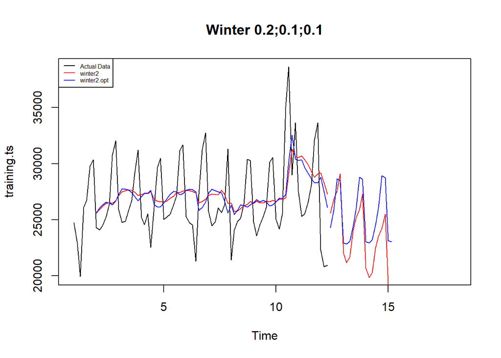

```r
#Plot time series
plot(training.ts,main="Winter 0.2;0.1;0.1",type="l",col="black",
     xlim=c(1,18),pch=12)
lines(xhat2,type="l",col="red")
lines(xhat2.opt,type="l",col="blue")
lines(forecast2,type="l",col="red")
lines(forecast2.opt,type="l",col="blue")
legend("topleft",c("Actual Data",expression(paste(winter2)),
                   expression(paste(winter2.opt))),cex=0.5,
       col=c("black","red","blue"),lty=1)
```

#### Akurasi Data Latih

```r
#Akurasi data training
SSE2<-winter2$SSE
MSE2<-winter2$SSE/length(training.ts)
RMSE2<-sqrt(MSE2)
fitted_values <- winter2$fitted[,1]
abs_error <- abs(training.ts - fitted_values)
MAPE2 <- mean(abs_error / training.ts * 100)

akurasi1 <- matrix(c(SSE2,MSE2,RMSE2))
row.names(akurasi1)<- c("SSE2", "MSE2", "RMSE2")
colnames(akurasi1) <- c("Akurasi lamda=0.2")
akurasi1
```

```
##       Akurasi lamda=0.2
## SSE2       4.456049e+08
## MSE2       5.570061e+06
## RMSE2      2.360098e+03
```

```r
SSE2.opt<-winter2.opt$SSE
MSE2.opt<-winter2.opt$SSE/length(training.ts)
RMSE2.opt<-sqrt(MSE2.opt)
fitted_values <- winter2.opt$fitted[,1]
abs_error <- abs(training.ts - fitted_values)
MAPE2.opt <- mean(abs_error / training.ts * 100)

akurasi1.opt <- matrix(c(SSE2.opt,MSE2.opt,RMSE2.opt))
row.names(akurasi1.opt)<- c("SSE2.opt", "MSE2.opt", "RMSE2.opt")
colnames(akurasi1.opt) <- c("Akurasi")
akurasi1.opt
```

```
##                Akurasi
## SSE2.opt  3.831162e+08
## MSE2.opt  4.788953e+06
## RMSE2.opt 2.188368e+03
```

```r
akurasi2.train = data.frame(Model_Winter = c("Winter 2","winter2 optimal"),
                            Nilai_SSE=c(SSE2,SSE2.opt),
                            Nilai_MSE=c(MSE2,MSE2.opt),Nilai_RMSE=c(RMSE2,RMSE2.opt),Nilai_MAPE=c(MAPE2,MAPE2.opt))
akurasi2.train
```

```
##      Model_Winter Nilai_SSE Nilai_MSE Nilai_RMSE Nilai_MAPE
## 1        Winter 2 445604876   5570061   2360.098   5.847583
## 2 winter2 optimal 383116207   4788953   2188.368   5.455351
```

Hasil analisis menggunakan Winter Multiplicative dengan nilai alpha, beta, dan gamma optimum menghasilkan nilai SSE, MSE, dan RMSE yang lebih kecil. Selain itu nilai MAPE juga lebih kecil serta dibawah 10% yang menandakan bahwa nilai ini dapat dikategorikan sebagai nilai akurasi yang sangat baik.

#### Akurasi Data Uji

```r
#Akurasi data testing
# Perhitungan untuk model winter2
SSEtesting2 <- winter2$SSE
MSEtesting2 <- SSEtesting2 / length(testing.ts)
RMSEtesting2 <- sqrt(MSEtesting2)
akurasi2 <- matrix(c(SSEtesting2, MSEtesting2, RMSEtesting2))
row.names(akurasi2) <- c("SSE2", "MSE2", "RMSE2")
colnames(akurasi2) <- c("Akurasi lambda=0.2")

# Perhitungan untuk model winter2.opt
SSEtesting2.opt <- winter2.opt$SSE
MSEtesting2.opt <- SSEtesting2.opt / length(testing.ts)
RMSEtesting2.opt <- sqrt(MSEtesting2.opt)
akurasi2.opt <- matrix(c(SSEtesting2.opt, MSEtesting2.opt, RMSEtesting2.opt))
row.names(akurasi2.opt) <- c("SSE2", "MSE2", "RMSE2")
colnames(akurasi2.opt) <- c("Akurasi Optimal")

akurasi2.test = data.frame(Model_Winter = c("Winter2","Winter2 optimal"),
                            Nilai_SSE=c(SSEtesting2,SSEtesting2.opt),
                            Nilai_MSE=c(MSEtesting2,MSEtesting2.opt), Nilai_RMSE=c(RMSEtesting2,RMSEtesting2.opt))
akurasi2.test
```

```
##      Model_Winter Nilai_SSE Nilai_MSE Nilai_RMSE
## 1         Winter2 445604876 445604876   21109.36
## 2 Winter2 optimal 383116207 383116207   19573.35
```

# Kesimpulan

setelah menggunakan beberapa metode dan juga membandingkan hasil nilai SSE, MSE, RMSE, dan juga MAPE. Didapatkan hasil terbaik dengan nilai SSE, MSE, RMSE, serta MAPE yang paling kecil yaitu menggunakan metode winter. Metode Winter sendiri dibagi menjadi 2, yaitu metode Winter Aditive dan Winter Multiplicative, setelah dianalisis pada kedua metode winter tersebut didapatkan hasil terbaik menggunakan nilai alpha, beta, dan juga gamma yang optimum.

Oleh karena itu, kedua nilai tersebut dibandingkan untuk menentukan metode winter terbaik yang akan digunakan.

```r
akurasi1.train
```

```
##      Model_Winter Nilai_SSE Nilai_MSE Nilai_RMSE Nilai_MAPE
## 1        Winter 1 419766100   5247076   2290.650   5.592465
## 2 Winter1 optimal 376836412   4710455   2170.358   5.493249
```

```r
akurasi2.train
```

```
##      Model_Winter Nilai_SSE Nilai_MSE Nilai_RMSE Nilai_MAPE
## 1        Winter 2 445604876   5570061   2360.098   5.847583
## 2 winter2 optimal 383116207   4788953   2188.368   5.455351
```

```r
akurasi1.test
```

```
##      Model_Winter Nilai_SSE Nilai_MSE
## 1        Winter 1 299358807 299358807
## 2 Winter1 optimal 143403777 143403777
```

```r
akurasi2.test
```

```
##      Model_Winter Nilai_SSE Nilai_MSE Nilai_RMSE
## 1         Winter2 445604876 445604876   21109.36
## 2 Winter2 optimal 383116207 383116207   19573.35
```

Dengan hasil pemulusan & peramalan sebagai berikut:

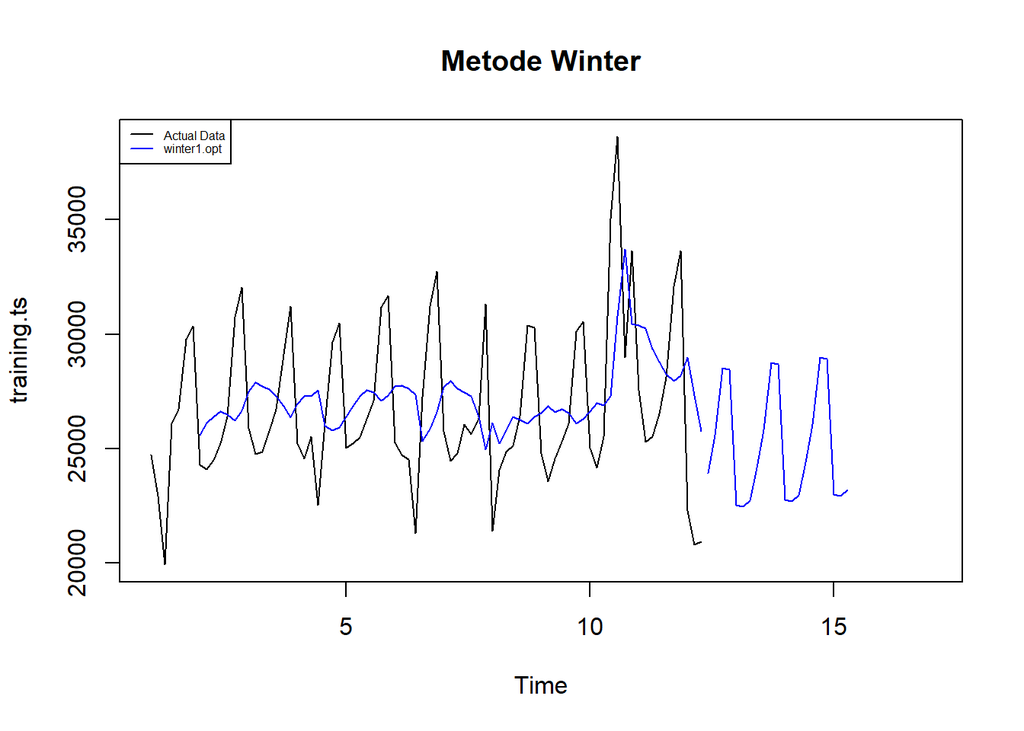

```r
#Plot time series hasil pemulusan & peramalan menggunakan metode Winter Aditive Optimum
forecast1.opt <- predict(winter1.opt, n.ahead = 21)
plot(training.ts, main="Metode Winter", type="l", col="black",
     xlim=c(1,17), pch=12)
lines(xhat1.opt, type="l", col="blue")
lines(forecast1.opt, type="l", col="blue")
legend("topleft", c("Actual Data", expression(paste(winter1.opt))),
       cex=0.5, col=c("black", "blue"), lty=1)
```

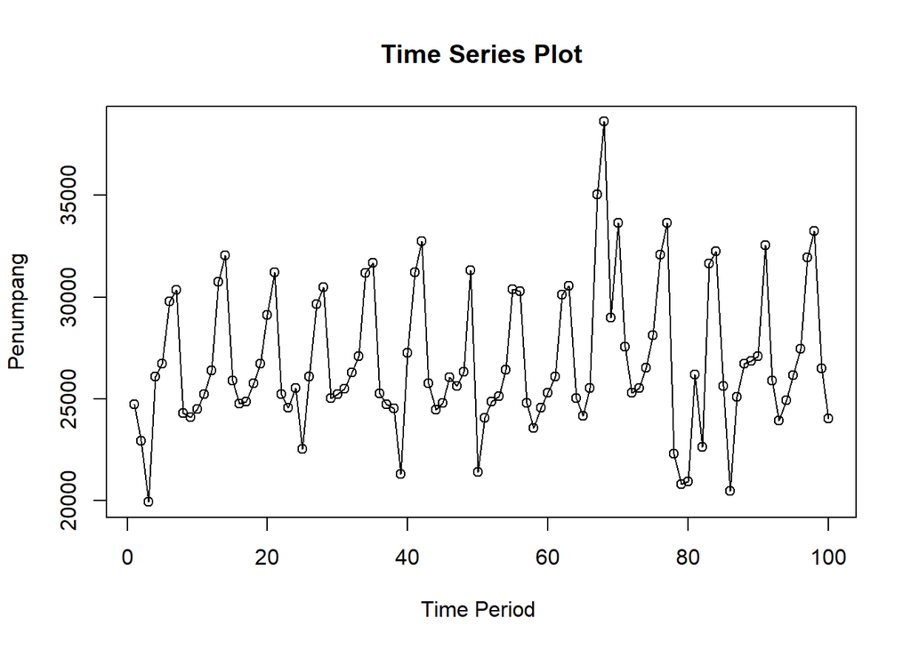

```r
ts.plot(data.ts, xlab="Time Period ", ylab="Penumpang",
        main = "Time Series Plot")
points(data.ts)
```